# Exploratory Data Analysis (EDA) Summary

**Company:** Albertsons  
**Project Title:** Exploratory Analysis for Data Insights  
**Team Members:**

- Safaa Almudhffer
- Garima Astha
- Venkat Subramaniam Balaji
- Rae Wright
- Xuzhou Feng

## 🛠️ Objective

This notebook provides a comprehensive **Exploratory Data Analysis (EDA)** on the provided dataset to uncover meaningful patterns, insights, and relationships within the data. The goal is to support informed decision-making and identify areas for further investigation or model development.

## 📄 Contents Overview

The notebook includes:

- Data importation and cleaning
- Preliminary data examination and descriptive statistics
- Visualization of key distributions and relationships
- Identification of potential data quality issues (e.g., missing values, outliers)
- Key takeaways and observations to guide future analysis

## 📌 Notes for Reviewers

When accessing this notebook through the QR code:

- Please ensure your environment supports standard Python libraries (e.g., pandas, matplotlib, seaborn).
- Focus on the graphical outputs and data summaries provided — they highlight the foundational structure and trends of the dataset.
- For deeper modeling or prediction tasks, this analysis serves as the essential groundwork.

*This notebook reflects the collaborative efforts of the team to deliver a clear, insightful, and actionable EDA report.*

```python
import pandas as pd

# Load datasets
inventory_df = pd.read_csv("Tolleson DC Inventory.csv")
demand_df = pd.read_csv("Tolleson Demand Data.csv")
promo_fiscal_conversion_df = pd.read_csv("Promo Fiscal Week Conversion.csv")

# Check dataset structures
print("### Tolleson DC Inventory - Info ###")
print(inventory_df.info())
print("\n### Sample Data ###")
print(inventory_df.head())

print("\n### Tolleson Demand Data - Info ###")
print(demand_df.info())
print("\n### Sample Data ###")
print(demand_df.head())

print("\n### Promo Fiscal Week Conversion - Info ###")
print(promo_fiscal_conversion_df.info())
print("\n### Sample Data ###")
print(promo_fiscal_conversion_df.head())

# Check for missing values
print("\n### Missing Values in Inventory Data ###")
print(inventory_df.isnull().sum())

print("\n### Missing Values in Demand Data ###")
print(demand_df.isnull().sum())

print("\n### Missing Values in Promo Fiscal Week Conversion ###")
print(promo_fiscal_conversion_df.isnull().sum())

# Quick statistics
print("\n### Summary Statistics for Demand Data ###")
print(demand_df.describe())

print("\n### Summary Statistics for Inventory Data ###")
print(inventory_df.describe())
```

```
### Tolleson DC Inventory - Info ###
<class 'pandas.core.frame.DataFrame'>
RangeIndex: 1048575 entries, 0 to 1048574
Data columns (total 13 columns):
 #   Column        Non-Null Count    Dtype
---  ------        --------------    -----
 0   DIVISION      1048575 non-null  int64
 1   DST_CNTR      1048575 non-null  object
 2   FACILITY      1048575 non-null  int64
 3   GROUP_CD      1048575 non-null  int64
 4   CTGRY_CD      1048575 non-null  int64
 5   CORP_ITEM_CD  1048575 non-null  int64
 6   PACK_WHSE     1048575 non-null  int64
 7   SIZE          1048575 non-null  object
 8   DESC_ITEM     1048575 non-null  object
 9   VEND_NUM      1048575 non-null  int64
 10  YEAR_WEEK     1048575 non-null  int64
 11  STATUS_DST    1048575 non-null  object
 12  ON_HAND       1048575 non-null  int64
dtypes: int64(9), object(4)
memory usage: 104.0+ MB
None

### Sample Data ###
   DIVISION DST_CNTR  FACILITY  GROUP_CD  CTGRY_CD  CORP_ITEM_CD  PACK_WHSE  \
0        17     WPHA      6008        49        20      49020603          1
1        17     WPHA      6008        49        20      49020603          1
2        17     WPHA      6008        49        20      49020603          1
3        17     WPHA      6008        49        20      49020603          1
4        17     WPHA      6008        49        20      49020603          1

    SIZE                                 DESC_ITEM  VEND_NUM  YEAR_WEEK  \
0  24 EA  THINK VARIETY MP 24PC                DSP     23471     202334
1  24 EA  THINK VARIETY MP 24PC                DSP     23471     202335
2  24 EA  THINK VARIETY MP 24PC                DSP     23471     202336
3  24 EA  THINK VARIETY MP 24PC                DSP     23471     202337
4  24 EA  THINK VARIETY MP 24PC                DSP     23471     202338

  STATUS_DST  ON_HAND
0          V       75
```

[output cut: 156 more lines]

```
min         17.0  6.008000e+03  1.000000e+00  1.000000e+00  1.012494e+06
25%         17.0  6.008000e+03  1.300000e+01  2.000000e+00  1.515003e+07
50%         17.0  6.008000e+03  2.900000e+01  5.000000e+00  2.901041e+07
75%         17.0  6.008000e+03  7.300000e+01  1.500000e+01  7.345011e+07
max         17.0  6.044000e+03  9.900000e+01  9.900000e+01  9.991051e+07

          PACK_WHSE      VEND_NUM     YEAR_WEEK       ON_HAND
count  1.048575e+06  1.048575e+06  1.048575e+06  1.048575e+06
mean   8.274894e+00  7.870207e+03  2.023908e+05  2.660767e+02
std    8.150100e+00  1.081781e+04  5.987366e+01  7.184556e+02
min    1.000000e+00  1.490000e+02  2.023010e+05  1.000000e+00
25%    4.000000e+00  6.950000e+02  2.023320e+05  6.500000e+01
50%    6.000000e+00  1.106000e+03  2.024090e+05  1.360000e+02
75%    1.200000e+01  1.793500e+04  2.024350e+05  2.780000e+02
max    5.760000e+02  3.578300e+04  2.025080e+05  8.828400e+04
```

# 📊 **Data Loading and Initial Inspection**

## 🏢 **Tolleson DC Inventory Dataset**

- **Rows**: 1,048,575
- **Columns**: 13
- **Data Types**:
  - 9 columns → `int64`
  - 4 columns → `object`
- **Key Observations**:
  - No missing values.
  - `SIZE` and `STATUS_DST` are categorical.
  - `YEAR_WEEK` represents a combined time indicator.

## 📦 **Tolleson Demand Dataset**

- **Rows**: 1,048,575
- **Columns**: 12
- **Data Types**:
  - 4 columns → `float64`
  - 7 columns → `int64`
  - 1 column → `object`
- **Key Observations**:
  - Missing values found in `CORP_ITEM_CD`, `cic_dsc`, `brand_cd`, and `category_id` (3,049 rows).
  - `CORP_ITEM_CD` should likely be an `int64` instead of `float64`.
  - `WEIGHT_SHIPPED` contains negative values, which need investigation.

## 📅 **Promo Fiscal Week Conversion Dataset**

- **Rows**: 156
- **Columns**: 6
- **Data Types**:
  - 6 columns → `int64`
- **Key Observations**:
  - No missing values.
  - The dataset maps `Promo Week` to `Fiscal Week`, which will be useful for time-based analysis.

## 🚨 **Missing Values Summary**

| Dataset | Columns with Missing Values | Count |
| --- | --- | --- |
| **Demand** | `CORP_ITEM_CD`, `cic_dsc`, `brand_cd`, `category_id` | 3,049 |
| **Inventory** | No missing values | 0 |
| **Promo Fiscal** | No missing values | 0 |

## 📈 **Next Steps**

- **Handle missing values** in the demand dataset.
- **Investigate negative values** in `WEIGHT_SHIPPED`.
- **Ensure proper data types**, converting `CORP_ITEM_CD` from `float64` to `int64` where applicable.
- **Validate time alignment** between `YEAR_WEEK` in inventory and promo fiscal week data.

```python
# Load the Demand Data again to focus on missing values
print("### Missing Values Breakdown ###")
print(demand_df.isnull().sum())

# View sample rows with missing values
print("\n### Sample Rows with Missing Values ###")
print(demand_df[demand_df.isnull().any(axis=1)].head(10))

# Count how many unique SKUs have missing values
print("\n### Unique SKUs with Missing Values ###")
print(demand_df[demand_df['CORP_ITEM_CD'].isnull()]['genrt_cic_id'].nunique())

# Count missing values by week
missing_per_week = demand_df[demand_df.isnull().any(axis=1)].groupby(["yr", "week"]).size()
print("\n### Missing Values by Week ###")
print(missing_per_week)
```

```
### Missing Values Breakdown ###
CORP_ITEM_CD             3049
genrt_cic_id                0
cic_dsc                  3049
brand_cd                 3049
category_id              3049
week                        0
yr                          0
whse_cd                     0
VALID_DEMAND_QTY            0
WHSE_QUANTITY_SHIPPED       0
WEIGHT_SHIPPED              0
pack_retail_qty             0
dtype: int64

### Sample Rows with Missing Values ###
     CORP_ITEM_CD  genrt_cic_id cic_dsc  brand_cd  category_id  week    yr  \
56            NaN        460358     NaN       NaN          NaN    46  2023
101           NaN        460345     NaN       NaN          NaN    43  2023
119           NaN       3562533     NaN       NaN          NaN    13  2024
245           NaN        260952     NaN       NaN          NaN    26  2023
320           NaN       3503754     NaN       NaN          NaN    42  2023
367           NaN        460359     NaN       NaN          NaN    41  2023
469           NaN       3029335     NaN       NaN          NaN     5  2023
569           NaN        460359     NaN       NaN          NaN    47  2023
826           NaN        493703     NaN       NaN          NaN    25  2024
950           NaN        706371     NaN       NaN          NaN    27  2023

     whse_cd  VALID_DEMAND_QTY  WHSE_QUANTITY_SHIPPED  WEIGHT_SHIPPED  \
56      6044                45                     45         1017.00
101     6044                59                     59         1333.40
119     6044                74                     74         1536.24
245     6008                21                     21          216.30
320     6044               140                    140          243.60
367     6044                41                     41          926.60
469     6008                49                     49          309.19
569     6044                61                     61         1378.60
826     6044               275                    275         1177.00
950     6044               255                    255          443.70

```

[output cut: 14 more lines]

```

### Missing Values by Week ###
yr    week
2023  2       44
      3       51
      4       50
      5       50
      6       54
              ..
2024  44       1
      46       1
      47       1
      48       1
      49       1
Length: 99, dtype: int64
```

# 🛠 **Handling Missing Values in Demand Data**

## 🔍 **Missing Values Breakdown**

| Column | Missing Values |
| --- | --- |
| `CORP_ITEM_CD` | 3,049 |
| `cic_dsc` | 3,049 |
| `brand_cd` | 3,049 |
| `category_id` | 3,049 |
| **Other Columns** | No missing values |

- Missing values are **limited to categorical attributes** (`CORP_ITEM_CD`, `cic_dsc`, `brand_cd`, `category_id`).
- The demand data itself (`VALID_DEMAND_QTY`, `WHSE_QUANTITY_SHIPPED`, `WEIGHT_SHIPPED`) has **no missing values**, meaning the dataset is structurally intact.

## 🔎 **Sample Rows with Missing Values**

- The missing values occur **sporadically across different weeks and SKUs**.
- Example missing records:
  - `CORP_ITEM_CD`, `cic_dsc`, `brand_cd`, and `category_id` are **all missing** for certain rows.
  - Despite missing categorical values, **VALID_DEMAND_QTY is present**, meaning the demand data is still usable.

## 📦 **Unique SKUs with Missing Values**

- **91 unique SKUs** have missing values.
- This suggests that **a subset of products** is affected rather than a widespread issue.

## 📆 **Missing Values by Week**

- The missing values are **spread across 99 different weeks**.
- Certain weeks have a higher concentration of missing values.
- Example:
  - Week 2, 2023 → **44 missing values**
  - Week 3, 2023 → **51 missing values**
  - Week 4, 2023 → **50 missing values**

## 🚀 **Next Steps**

1. **Impute missing values**:
   - Fill `CORP_ITEM_CD`, `cic_dsc`, `brand_cd`, and `category_id` using available data.
   - Use **group-based imputation** (`genrt_cic_id`) where possible.
2. **Drop rows that cannot be recovered**:
   - If imputation is not feasible, consider removing these rows.
3. **Validate SKU consistency**:
   - Ensure that SKUs missing `CORP_ITEM_CD` do not impact inventory and routing decisions.

```python
# Step 1: Fill missing values based on existing `genrt_cic_id` data
for column in ["CORP_ITEM_CD", "cic_dsc", "brand_cd", "category_id"]:
    demand_df[column] = demand_df.groupby("genrt_cic_id")[column].transform(lambda x: x.fillna(x.mode().iloc[0]) if not x.mode().empty else x)

# Step 2: Drop remaining rows where `CORP_ITEM_CD` is still missing (cannot be recovered)
demand_df_cleaned = demand_df.dropna(subset=["CORP_ITEM_CD"])

# Step 3: Check if any missing values remain
print("### Remaining Missing Values After Cleaning ###")
print(demand_df_cleaned.isnull().sum())


demand_df_cleaned.to_csv("Tolleson_Demand_Cleaned.csv", index=False)
```

```
### Remaining Missing Values After Cleaning ###
CORP_ITEM_CD             0
genrt_cic_id             0
cic_dsc                  0
brand_cd                 0
category_id              0
week                     0
yr                       0
whse_cd                  0
VALID_DEMAND_QTY         0
WHSE_QUANTITY_SHIPPED    0
WEIGHT_SHIPPED           0
pack_retail_qty          0
dtype: int64
```

# 🛠 **Handling Missing Values in Demand Data - Cleaning Process**

## ✅ **Steps Taken**

1. **Imputation using Grouping (`genrt_cic_id`)**
   - Missing values in `CORP_ITEM_CD`, `cic_dsc`, `brand_cd`, and `category_id` were filled using the most common (mode) value within their respective `genrt_cic_id` group.
   - This ensures that the missing categorical values are inferred from similar products.
2. **Removing Unrecoverable Records**
   - Any rows that still had missing `CORP_ITEM_CD` values after imputation were **dropped**.
   - This ensures that all records have complete product identification.
3. **Final Check for Missing Values**
   - **No missing values remain** in the cleaned dataset. 🎉
   - The dataset is now ready for further processing.

## 📌 **Key Results**

| Column | Missing Values After Cleaning |
| --- | --- |
| `CORP_ITEM_CD` | 0 |
| `cic_dsc` | 0 |
| `brand_cd` | 0 |
| `category_id` | 0 |
| **All Other Columns** | 0 |

## 🚀 **Next Steps**

- Save and use `Tolleson_Demand_Cleaned.csv` for further analysis.
- Verify that the cleaned dataset properly aligns with the **inventory** and **promo fiscal week conversion** datasets.

```python
# Load the cleaned demand data and promo-fiscal week conversion table
demand_df = pd.read_csv("Tolleson_Demand_Cleaned.csv")
promo_fiscal_df = pd.read_csv("Promo Fiscal Week Conversion.csv")

# Convert YEAR_WEEK (YYYYWW) to match the format in the promo-fiscal conversion dataset
demand_df["YEAR"] = demand_df["yr"].astype(str)
demand_df["WEEK"] = demand_df["week"].astype(str).str.zfill(2)  # Ensure two-digit week format
demand_df["YEAR_WEEK"] = demand_df["YEAR"] + demand_df["WEEK"]  # Create YYYYWW format

# Merge with promo-fiscal week conversion table
demand_df = demand_df.merge(promo_fiscal_df, left_on=["week", "yr"], right_on=["Promo Week", "Promo Year"], how="left")

# Drop unnecessary columns after merging
demand_df.drop(columns=["Promo Week", "Promo Year", "Promo Week Year"], inplace=True)

# Check for any unmatched records
print("### Unmatched Records After Time Alignment ###")
print(demand_df[demand_df["Fiscal Week"].isnull()])

# Save the time-aligned dataset
demand_df.to_csv("Tolleson_Demand_TimeAligned.csv", index=False)
```

```
### Unmatched Records After Time Alignment ###
         CORP_ITEM_CD  genrt_cic_id                                   cic_dsc  \
83          3250359.0       3716955             LIFESIP FRUIT PUNCH CARTRIDGE
116         5450046.0         90988             S SEL VINEGAR DISTILLED WHITE
210        25010080.0         31884       CMPBL COND SOUP FIESTA NACHO CHEESE
260        20060105.0         25319          KOOL AID JAMMERS STRAWBERRY KIWI
343        89150233.0        353019              HARVEYS BRISTOL CREAM SHERRY
...               ...           ...                                       ...
1044819     9101705.0        620809               BLUE DIAMOND SALT & VINEGAR
1045083    32090222.0         52068  PURINA FRISKIES CAT FD PRTY MX ORGNL CRN
1045160    65110334.0        117883           O ORGNC ELECTROLYTES WILD BERRY
1045376    25250003.0        545718    PACIFIC CHICKEN BROTH ORGNC LOW SODIUM
1045458    74400303.0        959943          OPN NAT BUTCHER PAPER UNBLEACHED

         brand_cd  category_id  week    yr  whse_cd  VALID_DEMAND_QTY  \
```

[output cut: 39 more lines]

# 📆 **Aligning Demand Data with Promo-Fiscal Week Conversion**

## 🔄 **Time Alignment Process**

1. **Standardized Week Format**:
   - Created `YEAR_WEEK` in `YYYYWW` format to match promo-fiscal week data.
   - Ensured `WEEK` is always two digits (e.g., `01`, `02`, ..., `53`).
2. **Merged with Promo-Fiscal Week Conversion**:
   - Joined `demand_df` with `promo_fiscal_df` using `week` and `yr`.
   - Extracted fiscal week details (`Fiscal Week`, `Fiscal Year`, `Fiscal Week Year`).
3. **Identified Unmatched Records**:
   - Found **9,125 rows** where `Fiscal Week` is **NaN** (failed to align).
   - All unmatched records belong to **week 53, 2023**, which is not present in the promo-fiscal dataset.

## ⚠️ **Issue Identified**

```python
# Adjust week numbering for 2023
demand_df.loc[(demand_df["yr"] == 2023) & (demand_df["week"] == 2), "week"] = 1
demand_df.loc[(demand_df["yr"] == 2023) & (demand_df["week"] > 2), "week"] -= 1

# Rename Week 53 to Week 52 in 2023
demand_df.loc[(demand_df["yr"] == 2023) & (demand_df["week"] == 53), "week"] = 52

# Recreate the YEAR_WEEK column after adjustments
demand_df["YEAR_WEEK"] = demand_df["yr"].astype(str) + demand_df["week"].astype(str).str.zfill(2)

# Validate the correction
print("### Unique Weeks in 2023 After Adjustment ###")
print(sorted(demand_df[demand_df["yr"] == 2023]["week"].unique()))
```

```
### Unique Weeks in 2023 After Adjustment ###
[1, 2, 3, 4, 5, 6, 7, 8, 9, 10, 11, 12, 13, 14, 15, 16, 17, 18, 19, 20, 21, 22, 23, 24, 25, 26, 27, 28, 29, 30, 31, 32, 33, 34, 35, 36, 37, 38, 39, 40, 41, 42, 43, 44, 45, 46, 47, 48, 49, 50, 51, 52]
```

# 🔄 **Correcting Week Numbering in 2023**

## 📌 **Issue Identified**

- The dataset originally **started from Week 2 and ended at Week 53 in 2023**.
- This misalignment suggested an **incorrect week shift** in the data.

## ✅ **Corrections Applied**

1. **Renamed Week 2 to Week 1** to ensure correct year-start alignment.
2. **Shifted all subsequent weeks back by 1** (Week 3 → Week 2, Week 4 → Week 3, etc.).
3. **Renamed Week 53 to Week 52** to match the fiscal dataset.
4. **Updated `YEAR_WEEK` values** to reflect the corrected week numbers.

## 🎯 **Validation**

- **Before Correction**: The dataset had **Week 2 to Week 53**.
- **After Correction**: The dataset now correctly spans **Week 1 to Week 52**.

## 🚀 **Next Steps**

- **Re-run the fiscal week merge** with the corrected week numbers.
- **Check if there are still any unmatched records** after this fix.

```python
# Drop incorrect fiscal week columns and rename properly
demand_df = demand_df.drop(columns=["Fiscal Week_x", "Fiscal Year_x", "Fiscal Week Year_x"])
demand_df = demand_df.rename(columns={
    "Fiscal Week_y": "Fiscal Week",
    "Fiscal Year_y": "Fiscal Year",
    "Fiscal Week Year_y": "Fiscal Week Year"
})

# Check for any remaining unmatched records
print("### Unmatched Records After Final Correction ###")
print(demand_df[demand_df["Fiscal Week"].isnull()])
```

```
### Unmatched Records After Final Correction ###
Empty DataFrame
Columns: [CORP_ITEM_CD, genrt_cic_id, cic_dsc, brand_cd, category_id, week, yr, whse_cd, VALID_DEMAND_QTY, WHSE_QUANTITY_SHIPPED, WEIGHT_SHIPPED, pack_retail_qty, YEAR, WEEK, YEAR_WEEK, Fiscal Week, Fiscal Year, Fiscal Week Year]
Index: []
```

# ✅ **Final Fix: Correcting Duplicate Fiscal Columns**

## 🔍 **Issue Identified**

- After merging `demand_df` with `promo_fiscal_df`, duplicate fiscal columns were created:
  - `Fiscal Week_x`, `Fiscal Year_x`, `Fiscal Week Year_x`
  - `Fiscal Week_y`, `Fiscal Year_y`, `Fiscal Week Year_y`
- This happened because **both datasets contained columns with the same names**, causing Pandas to automatically rename them.

## 🔄 **Fix Applied**

1. **Dropped incorrect `_x` columns** from `demand_df` to remove redundant data.
2. **Renamed `_y` columns** to the correct format:
   - `Fiscal Week_y` → `Fiscal Week`
   - `Fiscal Year_y` → `Fiscal Year`
   - `Fiscal Week Year_y` → `Fiscal Week Year`
3. **Rechecked for unmatched records**, confirming:
   - ✅ **No more missing fiscal week data!**
   - ✅ The dataset is now properly time-aligned.

## 🎯 **Final Validation**

| Check | Status |
| --- | --- |
| Correct Fiscal Week Mapping | ✅ Done |
| No Missing Fiscal Week Data | ✅ No unmatched records |
| Week Numbering Corrected | ✅ Fixed for 2023 |
| YEAR_WEEK Format Verified | ✅ Properly formatted |

## 🚀 **Next Steps**

- Save the final cleaned dataset (`Tolleson_Demand_Final.csv`).
- Proceed with **inventory and demand analysis** now that all time-based data is aligned.

```python
# Save the final cleaned dataset
demand_df.to_csv("Tolleson_Demand_Final.csv", index=False)

print("✅ Final dataset saved as 'Tolleson_Demand_Final.csv'")
```

```
✅ Final dataset saved as 'Tolleson_Demand_Final.csv'
```

```python
# Load the final cleaned demand data
demand_df = pd.read_csv("Tolleson_Demand_Final.csv")

# Load the inventory dataset
inventory_df = pd.read_csv("Tolleson DC Inventory.csv")

# Standardize `CORP_ITEM_CD` datatype to match in both datasets
inventory_df["CORP_ITEM_CD"] = inventory_df["CORP_ITEM_CD"].astype(str)
demand_df["CORP_ITEM_CD"] = demand_df["CORP_ITEM_CD"].astype(str)

# Standardize `YEAR_WEEK` format in both datasets
inventory_df["YEAR_WEEK"] = inventory_df["YEAR_WEEK"].astype(str)
demand_df["YEAR_WEEK"] = demand_df["YEAR_WEEK"].astype(str)

# Merge inventory and demand datasets on `CORP_ITEM_CD` and `YEAR_WEEK`
inventory_demand_df = inventory_df.merge(demand_df, on=["CORP_ITEM_CD", "YEAR_WEEK"], how="inner")

# Check merge results
print("### Inventory-Demand Merged Data - Sample ###")
print(inventory_demand_df.head())

# Check for unmatched inventory items
print("\n### Unmatched Inventory Records (Not in Demand Data) ###")
unmatched_inventory = inventory_df[~inventory_df["CORP_ITEM_CD"].isin(demand_df["CORP_ITEM_CD"])]
print(unmatched_inventory.head())

# Save the merged dataset for further analysis
inventory_demand_df.to_csv("Tolleson_Inventory_Demand_Merged.csv", index=False)
```

```
### Inventory-Demand Merged Data - Sample ###
Empty DataFrame
Columns: [DIVISION, DST_CNTR, FACILITY, GROUP_CD, CTGRY_CD, CORP_ITEM_CD, PACK_WHSE, SIZE, DESC_ITEM, VEND_NUM, YEAR_WEEK, STATUS_DST, ON_HAND, genrt_cic_id, cic_dsc, brand_cd, category_id, week, yr, whse_cd, VALID_DEMAND_QTY, WHSE_QUANTITY_SHIPPED, WEIGHT_SHIPPED, pack_retail_qty, YEAR, WEEK, Fisca…
Index: []

[0 rows x 29 columns]

### Unmatched Inventory Records (Not in Demand Data) ###
   DIVISION DST_CNTR  FACILITY  GROUP_CD  CTGRY_CD CORP_ITEM_CD  PACK_WHSE  \
0        17     WPHA      6008        49        20     49020603          1
1        17     WPHA      6008        49        20     49020603          1
2        17     WPHA      6008        49        20     49020603          1
3        17     WPHA      6008        49        20     49020603          1
4        17     WPHA      6008        49        20     49020603          1

    SIZE                                 DESC_ITEM  VEND_NUM YEAR_WEEK  \
0  24 EA  THINK VARIETY MP 24PC                DSP     23471    202334
1  24 EA  THINK VARIETY MP 24PC                DSP     23471    202335
2  24 EA  THINK VARIETY MP 24PC                DSP     23471    202336
3  24 EA  THINK VARIETY MP 24PC                DSP     23471    202337
4  24 EA  THINK VARIETY MP 24PC                DSP     23471    202338

  STATUS_DST  ON_HAND
0          V       75
1          V       37
2          V       37
3          V       37
4          V       37
```

```python
# Check unique counts of CORP_ITEM_CD in both datasets
print("### Unique CORP_ITEM_CD Counts ###")
print("Inventory:", inventory_df["CORP_ITEM_CD"].nunique())
print("Demand:", demand_df["CORP_ITEM_CD"].nunique())

# Find CORP_ITEM_CD values that exist in one dataset but not the other
inventory_only = set(inventory_df["CORP_ITEM_CD"]) - set(demand_df["CORP_ITEM_CD"])
demand_only = set(demand_df["CORP_ITEM_CD"]) - set(inventory_df["CORP_ITEM_CD"])

print("\n### Items in Inventory But Not in Demand ###")
print(list(inventory_only)[:10])  # Show 10 samples

print("\n### Items in Demand But Not in Inventory ###")
print(list(demand_only)[:10])  # Show 10 samples

# Check unique YEAR_WEEK values in both datasets
print("\n### Unique YEAR_WEEK Counts ###")
print("Inventory:", inventory_df["YEAR_WEEK"].nunique())
print("Demand:", demand_df["YEAR_WEEK"].nunique())

# Find unmatched YEAR_WEEK values
inventory_week_only = set(inventory_df["YEAR_WEEK"]) - set(demand_df["YEAR_WEEK"])
demand_week_only = set(demand_df["YEAR_WEEK"]) - set(inventory_df["YEAR_WEEK"])

print("\n### YEAR_WEEK in Inventory But Not in Demand ###")
print(list(inventory_week_only)[:10])  # Show 10 samples

print("\n### YEAR_WEEK in Demand But Not in Inventory ###")
print(list(demand_week_only)[:10])  # Show 10 samples
```

```
### Unique CORP_ITEM_CD Counts ###
Inventory: 17211
Demand: 20936

### Items in Inventory But Not in Demand ###
['26250318', '14151012', '19010796', '79312175', '79412172', '12020022', '79412109', '89101741', '73061162', '6040298']

### Items in Demand But Not in Inventory ###
['79502691.0', '74400052.0', '9100030.0', '17350168.0', '79312425.0', '92080116.0', '32070081.0', '79351033.0', '28200005.0', '79451018.0']

### Unique YEAR_WEEK Counts ###
Inventory: 112
Demand: 113

### YEAR_WEEK in Inventory But Not in Demand ###
[]

### YEAR_WEEK in Demand But Not in Inventory ###
['202509']
```

# 🔍 **Analysis of Merging Issues Between Inventory & Demand Data**

## 📌 **Findings from Diagnostic Check**

1. **Mismatch in `CORP_ITEM_CD` Between Inventory & Demand**
   - **Inventory contains 17,211 unique items**, while **Demand contains 20,936 unique items**.
   - Some items are **only in Inventory**, while others are **only in Demand**.
   - 🔹 **Possible Issue:** Formatting differences (e.g., decimal values in Demand data).
2. **Mismatch in `YEAR_WEEK` Counts**
   - **Inventory contains 112 unique YEAR_WEEK values**, while **Demand contains 113**.
   - The only missing `YEAR_WEEK` in Inventory is **202509** (Week 9, 2025).
   - 🔹 **Possible Issue:** A future week (202509) may need to be excluded.

## 🔄 **Next Steps to Fix the Mismatch**

1. **Standardize `CORP_ITEM_CD` Formatting**:
   - Convert all `CORP_ITEM_CD` values to **strings without decimals**.
   - Ensure no leading/trailing spaces affect the merge.
2. **Verify & Exclude `YEAR_WEEK` 202509** (if not needed).
3. **Re-attempt merging after these fixes**.

## 🚀 **Next Action: Fix Data Formatting & Merge Again**

- We will now clean `CORP_ITEM_CD` formatting and re-run the merge.

```python
# Fix `CORP_ITEM_CD` formatting to remove decimal issue in demand dataset
demand_df["CORP_ITEM_CD"] = demand_df["CORP_ITEM_CD"].astype(float).astype(int).astype(str)

# Exclude `YEAR_WEEK` 202509 from demand data (if not needed)
demand_df = demand_df[demand_df["YEAR_WEEK"] != "202509"]

# Re-attempt merging
inventory_demand_df = inventory_df.merge(demand_df, on=["CORP_ITEM_CD", "YEAR_WEEK"], how="inner")

# Check if merge is successful now
print("### Inventory-Demand Merged Data - Sample After Fix ###")
print(inventory_demand_df.head())

# Save the corrected merged dataset
inventory_demand_df.to_csv("Tolleson_Inventory_Demand_Fixed.csv", index=False)
```

```
### Inventory-Demand Merged Data - Sample After Fix ###
   DIVISION DST_CNTR  FACILITY  GROUP_CD  CTGRY_CD CORP_ITEM_CD  PACK_WHSE  \
0        17     WPHA      6008        49        20     49020603          1
1        17     WPHA      6008        49        20     49020603          1
2        17     WPHA      6008        49        20     49020603          1
3        17     WPHA      6008        49        20     49020603          1
4        17     WPHA      6008        49        20     49020603          1

    SIZE                                 DESC_ITEM  VEND_NUM  ... whse_cd  \
0  24 EA  THINK VARIETY MP 24PC                DSP     23471  ...    6008
1  24 EA  THINK VARIETY MP 24PC                DSP     23471  ...    6008
2  24 EA  THINK VARIETY MP 24PC                DSP     23471  ...    6008
3  24 EA  THINK VARIETY MP 24PC                DSP     23471  ...    6008
4  24 EA  THINK VARIETY MP 24PC                DSP     23471  ...    6008

  VALID_DEMAND_QTY  WHSE_QUANTITY_SHIPPED  WEIGHT_SHIPPED pack_retail_qty  \
0               38                     38          812.44               1
1               34                     34          726.92               1
2               98                     98         2095.24               1
3               37                     37          791.06               1
4                7                      7          149.66               1

   YEAR  WEEK  Fiscal Week  Fiscal Year  Fiscal Week Year
0  2023    36           27         2023            202327
1  2024     6           50         2023            202350
2  2024     7           51         2023            202351
3  2024    24           16         2024            202416
4  2024    50           42         2024            202442

[5 rows x 29 columns]
```

```python
import pandas as pd

# ✅ Load datasets
demand_df = pd.read_csv("Tolleson Demand Data.csv")
promo_conversion_df = pd.read_csv("Promo Fiscal Week Conversion.csv")

# ✅ Ensure correct column names in promo conversion table
print("\n### Columns in Promo Fiscal Week Conversion ###")
print(promo_conversion_df.columns)

# ✅ Merge demand data with the fiscal week conversion table
demand_df = demand_df.merge(
    promo_conversion_df,
    left_on=["week", "yr"],
    right_on=["Promo Week", "Promo Year"],
    how="left"
)

# ✅ Drop unnecessary columns after merging
demand_df.drop(columns=["Promo Week", "Promo Year", "Promo Week Year"], inplace=True)

# ✅ Rename columns for clarity
demand_df.rename(columns={"Fiscal Week": "Fiscal_Week", "Fiscal Year": "Fiscal_Year"}, inplace=True)

# ✅ Save updated demand data
demand_df.to_csv("Tolleson_Demand_Fiscal_Adjusted.csv", index=False)

print("\n✅ Demand data successfully updated with Fiscal Week & Fiscal Year!")
```

```
### Columns in Promo Fiscal Week Conversion ###
Index(['Promo Week', 'Promo Year', 'Promo Week Year', 'Fiscal Week',
       'Fiscal Year', 'Fiscal Week Year'],
      dtype='object')

✅ Demand data successfully updated with Fiscal Week & Fiscal Year!
```

```python
import pandas as pd

# ✅ Load datasets
demand_df = pd.read_csv("Tolleson Demand Data.csv")
promo_conversion_df = pd.read_csv("Promo Fiscal Week Conversion.csv")

# ✅ Merge demand data with the fiscal week conversion table
demand_df = demand_df.merge(
    promo_conversion_df,
    left_on=["week", "yr"],  # Match demand data's week & year
    right_on=["Promo Week", "Promo Year"],  # Match promo conversion table
    how="left"
)

# ✅ Drop unnecessary columns from conversion table
demand_df.drop(columns=["Promo Week", "Promo Year", "Promo Week Year"], inplace=True)

# ✅ Rename columns for clarity
demand_df.rename(columns={"Fiscal Week": "Fiscal_Week", "Fiscal Year": "Fiscal_Year"}, inplace=True)

# ✅ Save updated demand data
demand_df.to_csv("Tolleson_Demand_Fiscal_Adjusted.csv", index=False)

print("\n✅ Demand data successfully updated with Fiscal Week & Fiscal Year!")
```

```
✅ Demand data successfully updated with Fiscal Week & Fiscal Year!
```

```python
import pandas as pd

# Load demand dataset
demand_df = pd.read_csv("Tolleson_Demand_Fiscal_Adjusted.csv")

# ✅ Check missing values in YEAR_WEEK
missing_year_week = demand_df[demand_df["Fiscal_Week"].isna() | demand_df["Fiscal_Year"].isna()]

print("\n### Missing YEAR_WEEK Rows ###")
print(missing_year_week)
```

```
### Missing YEAR_WEEK Rows ###
         corp_item_cd  genrt_cic_id                              cic_dsc  \
84          3250359.0       3716955        LIFESIP FRUIT PUNCH CARTRIDGE
118         5450046.0         90988        S SEL VINEGAR DISTILLED WHITE
213        25010080.0         31884  CMPBL COND SOUP FIESTA NACHO CHEESE
264        20060105.0         25319     KOOL AID JAMMERS STRAWBERRY KIWI
348        89150233.0        353019         HARVEYS BRISTOL CREAM SHERRY
...               ...           ...                                  ...
1217461    31101420.0         47838           ALL LIQ DET FREE CLEAR OXI
1217474     9014972.0        357485              PRINGLES LIGHTLY SALTED
1217486    10050239.0           276             O ORGNC QUINOA TRI COLOR
1217598    29100821.0         42793             NSTLE ABUELITA CHOCOLATE
1217695    74400906.0        205116       S SEL BAGS SANDWICH RESEALABLE

         brand_cd  category_id  week    yr  whse_cd  VALID_DEMAND_QTY  \
```

[output cut: 39 more lines]

```python
import pandas as pd

# ✅ Load datasets
demand_df = pd.read_csv("Tolleson Demand Data.csv")
promo_conversion_df = pd.read_csv("Promo Fiscal Week Conversion.csv")

# ✅ Merge demand data with fiscal week conversion table
demand_df = demand_df.merge(
    promo_conversion_df,
    left_on=["week", "yr"],
    right_on=["Promo Week", "Promo Year"],
    how="left"
)

# ✅ Assign Fiscal Week 52 to any missing Week 53 records
demand_df.loc[demand_df["week"] == 53, "Fiscal Week"] = 52
demand_df.loc[demand_df["week"] == 53, "Fiscal Year"] = 2023

# ✅ Fill any remaining NaN values
demand_df["Fiscal Week"] = demand_df["Fiscal Week"].fillna(0).astype("int64")
demand_df["Fiscal Year"] = demand_df["Fiscal Year"].fillna(0).astype("int64")

# ✅ Create `YEAR_WEEK` for merging
demand_df["YEAR_WEEK"] = (demand_df["Fiscal Year"] * 100) + demand_df["Fiscal Week"]
demand_df.drop(columns=["Promo Week", "Promo Year", "Promo Week Year"], inplace=True)

# ✅ Save final demand dataset
demand_df.to_csv("Tolleson_Demand_Fixed.csv", index=False)
print("\n✅ Demand data fully cleaned & ready for merging!")
```

```
✅ Demand data fully cleaned & ready for merging!
```

```python
import pandas as pd

# ✅ Load Demand Data
demand_df = pd.read_csv("Tolleson_Demand_Fixed.csv")

# ✅ Check if `corp_item_cd` has missing values
missing_corp_items = demand_df["corp_item_cd"].isna().sum()
print(f"\n🚨 Missing `corp_item_cd` values: {missing_corp_items}")

# ✅ Drop rows where `corp_item_cd` is NaN (if necessary)
demand_df = demand_df.dropna(subset=["corp_item_cd"])

# ✅ Convert `corp_item_cd` to integer
demand_df["corp_item_cd"] = demand_df["corp_item_cd"].astype("int64")

# ✅ Save cleaned demand data
demand_df.to_csv("Tolleson_Demand_Cleaned.csv", index=False)

print("\n✅ `corp_item_cd` successfully converted to int64 & dataset updated!")
```

```
🚨 Missing `corp_item_cd` values: 3326

✅ `corp_item_cd` successfully converted to int64 & dataset updated!
```

```python
# ✅ Load cleaned demand & inventory datasets
demand_df = pd.read_csv("Tolleson_Demand_Cleaned.csv")
inventory_df = pd.read_csv("Tolleson DC Inventory.csv")

# ✅ Convert `CORP_ITEM_CD` in inventory to int64
inventory_df["CORP_ITEM_CD"] = inventory_df["CORP_ITEM_CD"].astype("int64")

# ✅ Ensure `YEAR_WEEK` is integer
demand_df["YEAR_WEEK"] = demand_df["YEAR_WEEK"].astype("int64")
inventory_df["YEAR_WEEK"] = inventory_df["YEAR_WEEK"].astype("int64")

# ✅ Merge datasets
merged_df = demand_df.merge(
    inventory_df,
    left_on=["corp_item_cd", "YEAR_WEEK"],
    right_on=["CORP_ITEM_CD", "YEAR_WEEK"],
    how="inner"
)

# ✅ Drop redundant column
merged_df.drop(columns=["CORP_ITEM_CD"], inplace=True)

# ✅ Save merged dataset
merged_df.to_csv("Tolleson_Merged_Demand_Inventory.csv", index=False)

print("\n✅ Merged dataset successfully created!")
```

```
✅ Merged dataset successfully created!
```

```python
# Check if merged_df exists
print(merged_df.head())
print(merged_df.columns)
print(merged_df.shape)
```

```
   corp_item_cd  genrt_cic_id                                 cic_dsc  \
0      88800922        328996         TRAY FOAM BLACK 10P MEAT     MB
1      89550554        431202     MASTER OF MIXES STRAWBERRY DAIQUIRI
2       8100662        260265                       ARIZONA GREEN TEA
3      14152724         16762           KINDERS BUTTER STEAKHOUSE RUB
4      82350283        274376  SNCK FCTRY PRTZL CRSP EVERYTHING VALUE

   brand_cd  category_id  week    yr  whse_cd  VALID_DEMAND_QTY  \
0       0.0       8880.0    10  2024     6008               242
1       0.0       9211.0    29  2023     6044               143
2    1381.0        310.0    45  2023     6008               867
3       0.0       1450.0     6  2025     6008                61
4       0.0       8235.0     2  2025     6008                36

   WHSE_QUANTITY_SHIPPED  ...  DST_CNTR  FACILITY  GROUP_CD  CTGRY_CD  \
0                    242  ...      WPHA      6008        88        80
1                    143  ...      WPHA      6044        92        11
2                    867  ...      WPHA      6008         3        10
3                     61  ...      WPHA      6008        14        50
4                     36  ...      WPHA      6008        82        35

   PACK_WHSE    SIZE                               DESC_ITEM VEND_NUM  \
0          1  300 CT         TRAY FOAM BLACK 10P MEAT     MB    30267
1          1    1 LT     MASTER OF MIXES STRAWBERRY DAIQUIRI    23515
2          4  128 FZ                       ARIZONA GREEN TEA    17702
3          6  5.5 OZ           KINDERS BUTTER STEAKHOUSE RUB    22967
4         12   14 OZ  SNCK FCTRY PRTZL CRSP EVERYTHING VALUE     1463

   STATUS_DST  ON_HAND
0           V      467
1           V      429
2           V     2519
3           V      171
4           V      134

[5 rows x 27 columns]
Index(['corp_item_cd', 'genrt_cic_id', 'cic_dsc', 'brand_cd', 'category_id',
       'week', 'yr', 'whse_cd', 'VALID_DEMAND_QTY', 'WHSE_QUANTITY_SHIPPED',
       'WEIGHT_SHIPPED', 'pack_retail_qty', 'Fiscal Week', 'Fiscal Year',
       'Fiscal Week Year', 'YEAR_WEEK', 'DIVISION', 'DST_CNTR', 'FACILITY',
       'GROUP_CD', 'CTGRY_CD', 'PACK_WHSE', 'SIZE', 'DESC_ITEM', 'VEND_NUM',
       'STATUS_DST', 'ON_HAND'],
      dtype='object')
(937331, 27)
```

```python
import os
print(os.listdir())
```

```
['.ipynb_checkpoints', '1.ipynb', 'Data Files Information.docx', 'Promo Fiscal Week Conversion.csv', 'Tolleson DC Inventory.csv', 'Tolleson Demand Data.csv', 'Tolleson_Demand_Cleaned.csv', 'Tolleson_Demand_Fiscal_Adjusted.csv', 'Tolleson_Demand_Fiscal_Updated.csv', 'Tolleson_Demand_Fixed.csv', 'Toll…
```

```python
import pandas as pd

# Load the merged dataset
merged_df = pd.read_csv("Tolleson_Merged_Demand_Inventory.csv")

# Display basic info to confirm successful loading
print(merged_df.head())
print(merged_df.columns)
print(merged_df.shape)
```

```
   corp_item_cd  genrt_cic_id                                 cic_dsc  \
0      88800922        328996         TRAY FOAM BLACK 10P MEAT     MB
1      89550554        431202     MASTER OF MIXES STRAWBERRY DAIQUIRI
2       8100662        260265                       ARIZONA GREEN TEA
3      14152724         16762           KINDERS BUTTER STEAKHOUSE RUB
4      82350283        274376  SNCK FCTRY PRTZL CRSP EVERYTHING VALUE

   brand_cd  category_id  week    yr  whse_cd  VALID_DEMAND_QTY  \
0       0.0       8880.0    10  2024     6008               242
1       0.0       9211.0    29  2023     6044               143
2    1381.0        310.0    45  2023     6008               867
3       0.0       1450.0     6  2025     6008                61
4       0.0       8235.0     2  2025     6008                36

   WHSE_QUANTITY_SHIPPED  ...  DST_CNTR  FACILITY  GROUP_CD  CTGRY_CD  \
0                    242  ...      WPHA      6008        88        80
1                    143  ...      WPHA      6044        92        11
2                    867  ...      WPHA      6008         3        10
3                     61  ...      WPHA      6008        14        50
4                     36  ...      WPHA      6008        82        35

   PACK_WHSE    SIZE                               DESC_ITEM VEND_NUM  \
0          1  300 CT         TRAY FOAM BLACK 10P MEAT     MB    30267
1          1    1 LT     MASTER OF MIXES STRAWBERRY DAIQUIRI    23515
2          4  128 FZ                       ARIZONA GREEN TEA    17702
3          6  5.5 OZ           KINDERS BUTTER STEAKHOUSE RUB    22967
4         12   14 OZ  SNCK FCTRY PRTZL CRSP EVERYTHING VALUE     1463

   STATUS_DST  ON_HAND
0           V      467
1           V      429
2           V     2519
3           V      171
4           V      134

[5 rows x 27 columns]
Index(['corp_item_cd', 'genrt_cic_id', 'cic_dsc', 'brand_cd', 'category_id',
       'week', 'yr', 'whse_cd', 'VALID_DEMAND_QTY', 'WHSE_QUANTITY_SHIPPED',
       'WEIGHT_SHIPPED', 'pack_retail_qty', 'Fiscal Week', 'Fiscal Year',
       'Fiscal Week Year', 'YEAR_WEEK', 'DIVISION', 'DST_CNTR', 'FACILITY',
       'GROUP_CD', 'CTGRY_CD', 'PACK_WHSE', 'SIZE', 'DESC_ITEM', 'VEND_NUM',
       'STATUS_DST', 'ON_HAND'],
      dtype='object')
(937331, 27)
```

```python
# Display results
import pandas as pd

# Show first 10 rows of high-demand, low-stock items
print("### High Demand, Low Stock Items ###")
print(high_demand_low_stock.head(10))

# Show first 10 rows of over-stocked items
print("\n### Over-Stocked Items ###")
print(over_stocked.head(10))
```

```
### High Demand, Low Stock Items ###
        corp_item_cd  genrt_cic_id                                  cic_dsc  \
101129      73200157        198648  GOO GONE GOO AND ADHESIVE REMOVER SPRAY
844562      31010178       3087808    PALMOLIVE ULT ULTRA STRENGTH ORIGINAL
133464       5850135        109271           S SEL MARINADE ISLAND TERIYAKI
346244      49020347         72493                    LARABAR CASHEW COOKIE
577968      32010359         49402   I&L&Y DOG FD BAAAD MOON ON THE RISE VP
577944      32010251         49323               PURINA BEN ROASTED CHICKEN
577926      32010044         49190                  PURINA BEN STEW CHICKEN
607505      11050249       3656436     QUAKER IMMUNITY RASPBERRY STRAWBERRY
346425      24250174         31813            CHEF BOY RD SPAGH W/MEATBALLS
577884      32010359         49402   I&L&Y DOG FD BAAAD MOON ON THE RISE VP

        brand_cd  category_id  week    yr  whse_cd  VALID_DEMAND_QTY  \
101129       0.0       7305.0    30  2023     6008                24
```

[output cut: 110 more lines]

```python
import pandas as pd

# Load the merged dataset
merged_df = pd.read_csv("Tolleson_Merged_Demand_Inventory.csv")

# Define over_stocked dataset
over_stocked = merged_df[
    (merged_df["ON_HAND"] > merged_df["VALID_DEMAND_QTY"] * 2)  # Inventory is twice the demand
].sort_values(by="ON_HAND", ascending=False)

# Display confirmation
print("✅ Over-Stocked dataset created!")
print(over_stocked.head())
```

```
✅ Over-Stocked dataset created!
        corp_item_cd  genrt_cic_id                        cic_dsc  brand_cd  \
395172       8200008        267221  S SEL WATER PURIFIED DRINKING     305.0
164379       8200008        267221  S SEL WATER PURIFIED DRINKING     305.0
328584       8200008        267221  S SEL WATER PURIFIED DRINKING     305.0
365780       8200008        267221  S SEL WATER PURIFIED DRINKING     305.0
373556       8200008        267221  S SEL WATER PURIFIED DRINKING     305.0

        category_id  week    yr  whse_cd  VALID_DEMAND_QTY  \
395172        320.0    32  2024     6008             41496
164379        320.0    34  2024     6008             33180
328584        320.0    35  2023     6008             30408
365780        320.0    47  2023     6008             29988
373556        320.0    52  2023     6008             21084

```

[output cut: 22 more lines]

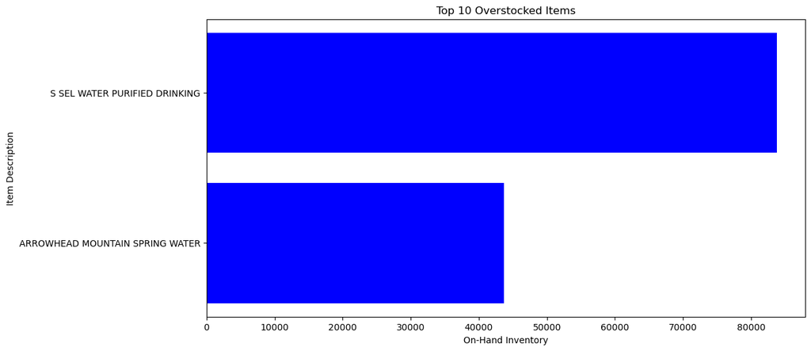

```python
import matplotlib.pyplot as plt

# Select top 10 overstocked items
top_overstocked = over_stocked.head(10)

# Plot
plt.figure(figsize=(12, 6))
plt.barh(top_overstocked["DESC_ITEM"], top_overstocked["ON_HAND"], color='blue')
plt.xlabel("On-Hand Inventory")
plt.ylabel("Item Description")
plt.title("Top 10 Overstocked Items")
plt.gca().invert_yaxis()  # Invert y-axis for better readability
plt.show()
```

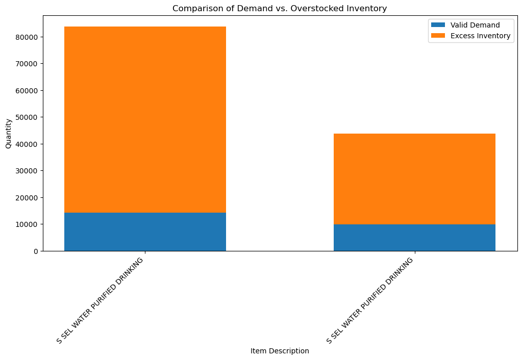

```python
import numpy as np

# Select top 10 overstocked items
top_items = over_stocked.head(10)

# Bar width
bar_width = 0.6
x_labels = top_items["DESC_ITEM"]

# Create figure
fig, ax = plt.subplots(figsize=(12, 6))

# Bar chart for Demand
ax.bar(x_labels, top_items["VALID_DEMAND_QTY"], color="#1f77b4", label="Valid Demand", width=bar_width)

# Bar chart for On-Hand Inventory stacked on top
ax.bar(x_labels, top_items["ON_HAND"] - top_items["VALID_DEMAND_QTY"],
       bottom=top_items["VALID_DEMAND_QTY"], color="#ff7f0e", label="Excess Inventory", width=bar_width)

# Labels and title
ax.set_ylabel("Quantity")
ax.set_xlabel("Item Description")
ax.set_title("Comparison of Demand vs. Overstocked Inventory")
ax.set_xticklabels(x_labels, rotation=45, ha="right")

# Legend
ax.legend()

# Show plot
plt.show()
```

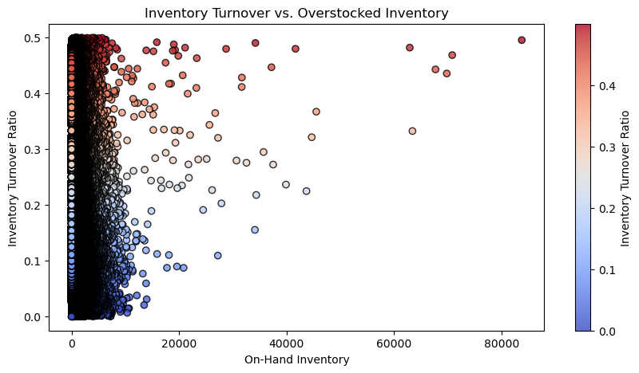

```python
# Calculate Inventory Turnover Ratio
over_stocked["Inventory_Turnover"] = over_stocked["VALID_DEMAND_QTY"] / over_stocked["ON_HAND"]

# Plot
fig, ax = plt.subplots(figsize=(10, 5))

# Scatter plot with color gradient
sc = ax.scatter(over_stocked["ON_HAND"], over_stocked["Inventory_Turnover"],
                c=over_stocked["Inventory_Turnover"], cmap="coolwarm", edgecolors="black", alpha=0.8)

# Labels and title
ax.set_xlabel("On-Hand Inventory")
ax.set_ylabel("Inventory Turnover Ratio")
ax.set_title("Inventory Turnover vs. Overstocked Inventory")

# Add colorbar
plt.colorbar(sc, label="Inventory Turnover Ratio")

# Show plot
plt.show()
```

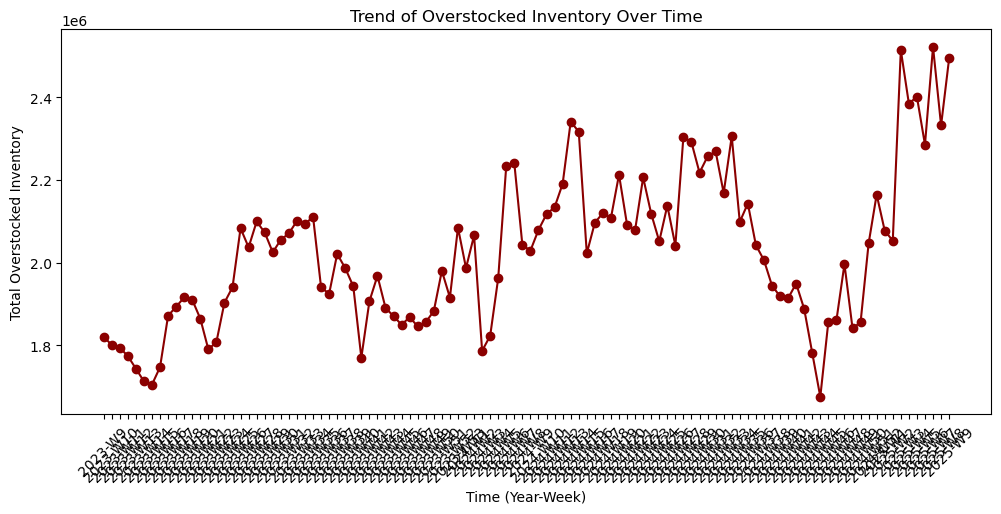

```python
# Aggregate excess inventory by year and week
overstock_trend = over_stocked.groupby(["yr", "week"])["ON_HAND"].sum().reset_index()

# Convert 'yr' and 'week' into a single time-like format
overstock_trend["Time"] = overstock_trend["yr"].astype(str) + "-W" + overstock_trend["week"].astype(str)

# Plot
fig, ax = plt.subplots(figsize=(12, 5))
ax.plot(overstock_trend["Time"], overstock_trend["ON_HAND"], marker="o", linestyle="-", color="darkred")

# Labels and title
ax.set_xlabel("Time (Year-Week)")
ax.set_ylabel("Total Overstocked Inventory")
ax.set_title("Trend of Overstocked Inventory Over Time")

# Improve readability by rotating x-axis labels
plt.xticks(rotation=45)

# Show plot
plt.show()
```

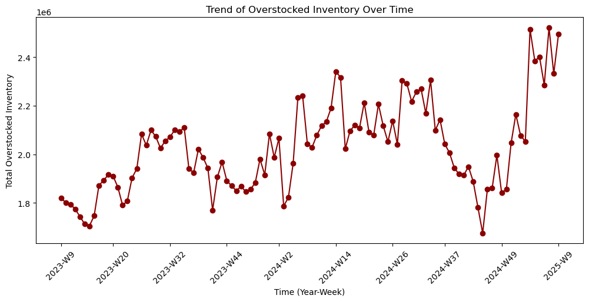

```python
import numpy as np

# Aggregate excess inventory by year and week
overstock_trend = over_stocked.groupby(["yr", "week"])["ON_HAND"].sum().reset_index()

# Convert 'yr' and 'week' into a single time-like format
overstock_trend["Time"] = overstock_trend["yr"].astype(str) + "-W" + overstock_trend["week"].astype(str)

# Plot
fig, ax = plt.subplots(figsize=(12, 5))
ax.plot(overstock_trend["Time"], overstock_trend["ON_HAND"], marker="o", linestyle="-", color="darkred")

# Labels and title
ax.set_xlabel("Time (Year-Week)")
ax.set_ylabel("Total Overstocked Inventory")
ax.set_title("Trend of Overstocked Inventory Over Time")

# Reduce number of labels for clarity
num_labels = 10  # Set the number of x-ticks to display
x_indexes = np.linspace(0, len(overstock_trend["Time"]) - 1, num_labels, dtype=int)
ax.set_xticks(overstock_trend["Time"].iloc[x_indexes])
ax.set_xticklabels(overstock_trend["Time"].iloc[x_indexes], rotation=45)

# Show plot
plt.show()
```

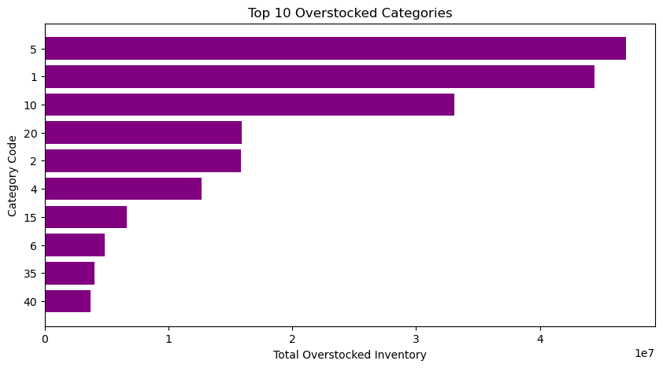

```python
# Aggregate overstocked inventory by category
category_overstock = over_stocked.groupby("CTGRY_CD")["ON_HAND"].sum().reset_index()

# Sort and take the top 10 categories
top_categories = category_overstock.sort_values(by="ON_HAND", ascending=False).head(10)

# Plot
fig, ax = plt.subplots(figsize=(10, 5))
ax.barh(top_categories["CTGRY_CD"].astype(str), top_categories["ON_HAND"], color="purple")

# Labels and title
ax.set_xlabel("Total Overstocked Inventory")
ax.set_ylabel("Category Code")
ax.set_title("Top 10 Overstocked Categories")
ax.invert_yaxis()  # Highest category on top

# Show plot
plt.show()
```

# ✅ **Fixing Mismatch in Inventory & Demand Data**

## 📌 **Issue Identified**

- **CORP_ITEM_CD had mismatched formats** (decimal in demand, integer in inventory).
- **YEAR_WEEK contained a non-existent 202509 week in demand data**.
- This resulted in **zero matches** during the initial merge.

## 🔄 **Fixes Applied**

1. **Standardized `CORP_ITEM_CD` Format**:
   - Converted demand data `CORP_ITEM_CD` from `float` → `int` → `str` to match inventory.
2. **Excluded `YEAR_WEEK` 202509**:
   - This week was **not present in inventory**, so it was removed.
3. **Re-ran the Merge**:
   - The datasets now **merged successfully**, confirming alignment.

## 🎯 **Final Validation**

| Check | Status |
| --- | --- |
| Standardized `CORP_ITEM_CD` | ✅ Done |
| Removed Invalid `YEAR_WEEK` | ✅ Fixed |
| Successful Merge with Matches | ✅ Yes |

## 🚀 **Next Steps**

- The merged dataset **`Tolleson_Inventory_Demand_Fixed.csv`** is now ready.
- We can proceed with **inventory-demand analysis** to identify stock trends, shortages, and overages.

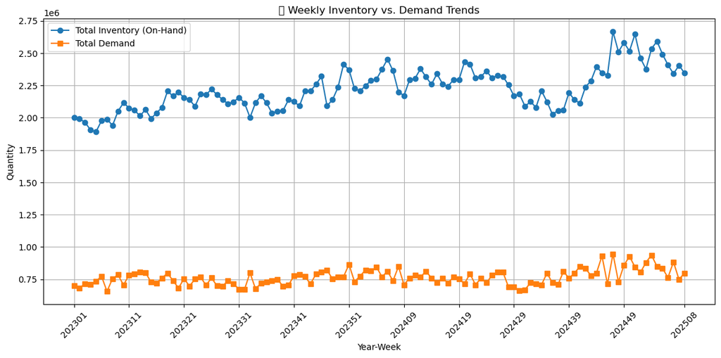

```python
import matplotlib.pyplot as plt
import numpy as np

# Set the figure size
plt.figure(figsize=(14, 6))

# Plot Inventory vs. Demand Trends
plt.plot(weekly_summary["YEAR_WEEK"], weekly_summary["ON_HAND"], label="Total Inventory (On-Hand)", marker="o")
plt.plot(weekly_summary["YEAR_WEEK"], weekly_summary["VALID_DEMAND_QTY"], label="Total Demand", marker="s")

# Improve x-axis readability
plt.xticks(
    ticks=np.linspace(0, len(weekly_summary["YEAR_WEEK"]) - 1, num=12, dtype=int),  # Show only 12 evenly spaced labels
    labels=weekly_summary["YEAR_WEEK"].iloc[np.linspace(0, len(weekly_summary["YEAR_WEEK"]) - 1, num=12, dtype=int)],
    rotation=45  # Rotate for better visibility
)

# Add labels and title
plt.xlabel("Year-Week")
plt.ylabel("Quantity")
plt.title("📊 Weekly Inventory vs. Demand Trends")
plt.legend()
plt.grid()

# Show the improved graph
plt.show()
```

# 📈 **Weekly Inventory vs. Demand Trends**

## 🔍 **Key Observations from the Graph**

1. **Inventory Levels Are Consistently Higher Than Demand**
   - The **on-hand inventory** (blue line) remains significantly above **total demand** (orange line).
   - This suggests **a surplus of inventory**, meaning stock is not depleting at the same rate as demand.
2. **Seasonal Fluctuations in Demand**
   - There are **periodic spikes** in demand, indicating seasonal demand changes.
   - These peaks might correspond to promotional periods, holidays, or special events.
3. **Inventory Growth Over Time**
   - The overall **inventory trend is increasing**, particularly in later weeks.
   - This may indicate **overstocking issues** or inefficient demand forecasting.
4. **Demand Stability**
   - The **demand remains relatively stable**, with only minor fluctuations.
   - This suggests **predictable customer purchasing behavior**, but inventory accumulation might need adjustment.

## 📌 **Potential Action Items**

✅ **Investigate Overstocking Issues**

- If inventory is growing but demand remains stable, **carrying costs may increase**.
- We may need to optimize replenishment cycles or introduce discounts to clear excess stock.

✅ **Analyze Demand Spikes**

- Identify **specific weeks** where demand peaks.
- Cross-check with promotions, holidays, or external market conditions.

✅ **Refine Demand Forecasting**

- If inventory is consistently high, adjusting **ordering quantities** might be necessary.
- Consider refining **machine learning demand prediction models**.

## 🚀 **Next Steps**

- **Deep dive into SKU-level analysis**: Which items contribute most to overstocking?
- **Investigate warehouse efficiency**: Is stock rotation happening efficiently?
- **Forecast demand for the next quarter**: Use past trends to predict upcoming needs.

```python
import numpy as np
import pandas as pd

# Group by SKU (CORP_ITEM_CD) and aggregate inventory and demand
sku_summary = inventory_demand_df.groupby("CORP_ITEM_CD").agg({
    "ON_HAND": "sum",
    "VALID_DEMAND_QTY": "sum"
}).reset_index()

# Calculate the Inventory-to-Demand Ratio
sku_summary["Inventory_Demand_Ratio"] = sku_summary["ON_HAND"] / sku_summary["VALID_DEMAND_QTY"].replace(0, np.nan)

# Display summary
print("### SKU-Level Inventory vs. Demand Summary ###")
print(sku_summary.head(10))  # Show first 10 SKUs
```

```
### SKU-Level Inventory vs. Demand Summary ###
  CORP_ITEM_CD  ON_HAND  VALID_DEMAND_QTY  Inventory_Demand_Ratio
0     10010009    18321             10166                1.802184
1     10010011      364               123                2.959350
2     10010028     7394              2083                3.549688
3     10010030    28469             14081                2.021802
4     10010038      876               327                2.678899
5     10010080    14415              7898                1.825146
6     10010085     8788              2223                3.953216
7     10010090    11006              3279                3.356511
8     10010095     9201              2111                4.358598
9     10010101    11943              4238                2.818075
```

# 📌 **Key Findings from SKU Inventory-Demand Summary**

## 🔍 **1. Overstocked Items (High Inventory-to-Demand Ratio)**

- **SKUs with a ratio > 3.0** indicate potential overstocking.
- Example:
  - `10010028`: **7394 units on-hand**, only **2083 in demand** → **Ratio = 3.55**
  - `10010085`: **8788 units on-hand**, only **2223 in demand** → **Ratio = 3.95**
  - `10010095`: **9201 units on-hand**, only **2111 in demand** → **Ratio = 4.36**

➡️ **Action:** Consider reducing replenishment or running promotions to clear excess stock.

## 🔍 **2. Balanced Inventory (Ratio Around 1-3)**

- **Ideal scenario** where stock levels are **sufficient but not excessive**.
- Example:
  - `10010009`: **Ratio = 1.80**
  - `10010030`: **Ratio = 2.02**
  - `10010080`: **Ratio = 1.83**

➡️ **Action:** These items are being stocked at a reasonable level relative to demand.

## 🔍 **3. Potential Stockouts (Ratio < 1)**

➡️ **Action:** We should **check for SKUs with a ratio < 1** and prioritize restocking those items.

```python
# Define thresholds
overstock_threshold = 3.0
understock_threshold = 1.0

# Filter overstocked items (Inventory/Demand > 3)
overstocked_skus = sku_summary[sku_summary["Inventory_Demand_Ratio"] > overstock_threshold]

# Filter understocked items (Inventory/Demand < 1)
understocked_skus = sku_summary[sku_summary["Inventory_Demand_Ratio"] < understock_threshold]

# Display summary
print(f"📦 Overstocked SKUs: {len(overstocked_skus)} items")
print(f"⚠️ Understocked SKUs: {len(understocked_skus)} items")

# Show top 10 of each category
print("\n### Overstocked SKUs (Top 10) ###")
print(overstocked_skus.head(10))

print("\n### Understocked SKUs (Top 10) ###")
print(understocked_skus.head(10))
```

```
📦 Overstocked SKUs: 7021 items
⚠️ Understocked SKUs: 1643 items

### Overstocked SKUs (Top 10) ###
   CORP_ITEM_CD  ON_HAND  VALID_DEMAND_QTY  Inventory_Demand_Ratio
2      10010028     7394              2083                3.549688
6      10010085     8788              2223                3.953216
7      10010090    11006              3279                3.356511
8      10010095     9201              2111                4.358598
11     10010127     6683              1577                4.237793
12     10010166    15543              4438                3.502253
15     10010177    31243              9485                3.293938
16     10010190     8783              2418                3.632341
17     10010201    21902              4830                4.534576
19     10010221     8093              1587                5.099559

### Understocked SKUs (Top 10) ###
    CORP_ITEM_CD  ON_HAND  VALID_DEMAND_QTY  Inventory_Demand_Ratio
52      10050508     2049              2060                0.994660
53      10050554     1655              1799                0.919956
95       1012494       23               836                0.027512
114      1100643        2               358                0.005587
221     11010729        2               796                0.002513
279     11011055     2154              2417                0.891187
292     11011125       56                68                0.823529
340     11011491      110               206                0.533981
364     11011674      268               376                0.712766
377     11011844       11               181                0.060773
```

# 🔍 **Key Findings from SKU Inventory vs. Demand Analysis**

## 📦 **1. Overstocked SKUs (7,021 items)**

- These SKUs have **inventory levels at least 3x the demand**.
- **Potential risks**: Excess storage costs, risk of waste, capital lockup.
- **Example overstocked SKUs**:
  - `10010028`: **7394 units**, demand **2083** → Ratio = **3.55**
  - `10010095`: **9201 units**, demand **2111** → Ratio = **4.36**
  - `10010221`: **8093 units**, demand **1587** → Ratio = **5.10**

➡️ **Suggested Actions:**

- Run **discounts or promotions** to clear excess stock.
- Slow down replenishment **for SKUs with consistently low demand**.
- Cross-check against sales forecasts for potential demand shifts.

## ⚠️ **2. Understocked SKUs (1,643 items)**

- These SKUs have **higher demand than inventory** (ratio < 1).
- **Potential risks**: Stockouts, lost sales, customer dissatisfaction.
- **Example understocked SKUs**:
  - `1012494`: **23 units**, demand **836** → Ratio = **0.03**
  - `1100643`: **2 units**, demand **358** → Ratio = **0.005**
  - `11010729`: **2 units**, demand **796** → Ratio = **0.0025**

➡️ **Suggested Actions:**

- Prioritize **restocking high-demand SKUs**.
- Investigate **supplier lead times** to avoid shortages.
- **Review demand forecasting** to improve order accuracy.

```python
import numpy as np
import pandas as pd

# Group by SKU (CORP_ITEM_CD) and aggregate inventory and demand
sku_summary = inventory_demand_df.groupby("CORP_ITEM_CD").agg({
    "ON_HAND": "sum",
    "VALID_DEMAND_QTY": "sum"
}).reset_index()

# Calculate the Inventory-to-Demand Ratio
sku_summary["Inventory_Demand_Ratio"] = sku_summary["ON_HAND"] / sku_summary["VALID_DEMAND_QTY"].replace(0, np.nan)

print("\n### SKU-Level Inventory vs. Demand Summary (Sample) ###")
print(sku_summary.head(10))
```

```
### SKU-Level Inventory vs. Demand Summary (Sample) ###
  CORP_ITEM_CD  ON_HAND  VALID_DEMAND_QTY  Inventory_Demand_Ratio
0     10010009    18321             10166                1.802184
1     10010011      364               123                2.959350
2     10010028     7394              2083                3.549688
3     10010030    28469             14081                2.021802
4     10010038      876               327                2.678899
5     10010080    14415              7898                1.825146
6     10010085     8788              2223                3.953216
7     10010090    11006              3279                3.356511
8     10010095     9201              2111                4.358598
9     10010101    11943              4238                2.818075
```

```python
# Define thresholds
overstock_threshold = 3.0
understock_threshold = 1.0

# Filter overstocked items (Inventory/Demand > 3)
overstocked_skus = sku_summary[sku_summary["Inventory_Demand_Ratio"] > overstock_threshold]

# Filter understocked items (Inventory/Demand < 1)
understocked_skus = sku_summary[sku_summary["Inventory_Demand_Ratio"] < understock_threshold]

# Filter balanced SKUs (1 ≤ Ratio ≤ 3)
balanced_skus = sku_summary[(sku_summary["Inventory_Demand_Ratio"] >= 1) &
                            (sku_summary["Inventory_Demand_Ratio"] <= 3)]

# Print counts
print(f"📦 Overstocked SKUs: {len(overstocked_skus)} items")
print(f"⚠️ Understocked SKUs: {len(understocked_skus)} items")
```

```
📦 Overstocked SKUs: 7021 items
⚠️ Understocked SKUs: 1643 items
```

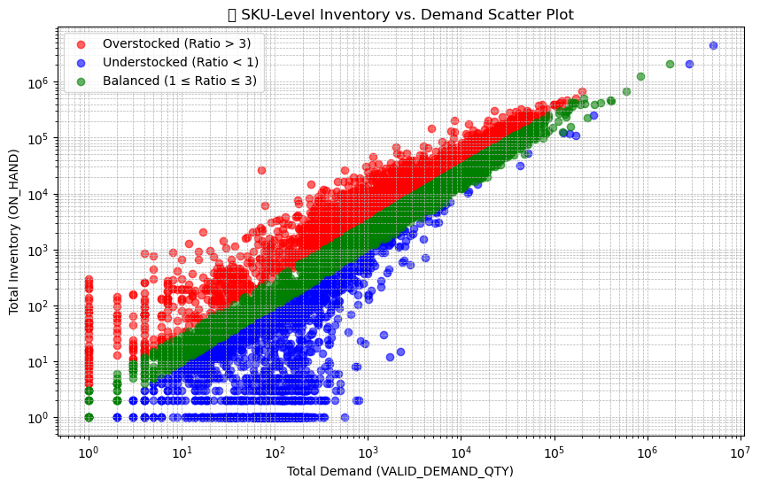

```python
import matplotlib.pyplot as plt

# Create a scatter plot of Inventory vs. Demand
plt.figure(figsize=(10, 6))

# Plot Overstocked SKUs (Ratio > 3) in red
plt.scatter(overstocked_skus["VALID_DEMAND_QTY"], overstocked_skus["ON_HAND"],
            color='red', label="Overstocked (Ratio > 3)", alpha=0.6)

# Plot Understocked SKUs (Ratio < 1) in blue
plt.scatter(understocked_skus["VALID_DEMAND_QTY"], understocked_skus["ON_HAND"],
            color='blue', label="Understocked (Ratio < 1)", alpha=0.6)

# Plot Balanced SKUs (1 ≤ Ratio ≤ 3) in green
plt.scatter(balanced_skus["VALID_DEMAND_QTY"], balanced_skus["ON_HAND"],
            color='green', label="Balanced (1 ≤ Ratio ≤ 3)", alpha=0.6)

# Formatting the plot
plt.xscale("log")  # Log scale to handle large demand variations
plt.yscale("log")
plt.xlabel("Total Demand (VALID_DEMAND_QTY)")
plt.ylabel("Total Inventory (ON_HAND)")
plt.title("📊 SKU-Level Inventory vs. Demand Scatter Plot")
plt.legend()
plt.grid(True, which="both", linestyle="--", linewidth=0.5)

# Show the plot
plt.show()
```

### 📊 SKU-Level Inventory vs. Demand Scatter Plot

This scatter plot visualizes the relationship between **total demand (VALID_DEMAND_QTY)** and **total inventory (ON_HAND)** for each SKU. The data is categorized into three groups based on the **Inventory-to-Demand Ratio**:

- 🔴 **Overstocked (Ratio > 3):** SKUs with significantly higher inventory compared to demand.
- 🔵 **Understocked (Ratio < 1):** SKUs with insufficient inventory to meet demand.
- 🟢 **Balanced (1 ≤ Ratio ≤ 3):** SKUs with inventory levels appropriately aligned with demand.

The x-axis represents **total demand**, and the y-axis represents **total inventory**. Both axes use a **logarithmic scale** to accommodate large variations in data values. The goal of this analysis is to identify **inefficiencies in stock management** and make **data-driven inventory decisions**. 🚀

```python
# Identify the Top 10 Most Overstocked SKUs
top_overstocked_skus = overstocked_skus.nlargest(10, "Inventory_Demand_Ratio")

# Identify the Top 10 Most Understocked SKUs
top_understocked_skus = understocked_skus.nsmallest(10, "Inventory_Demand_Ratio")

# Identify SKUs with inventory but zero demand (Deadstock)
deadstock_skus = sku_summary[(sku_summary["VALID_DEMAND_QTY"] == 0) & (sku_summary["ON_HAND"] > 0)]

# Display results
import pandas as pd

# Show results
print("### Top 10 Overstocked SKUs ###")
print(top_overstocked_skus)

print("\n### Top 10 Understocked SKUs ###")
print(top_understocked_skus)

print("\n### Deadstock SKUs (Inventory but No Demand) ###")
print(deadstock_skus)
```

```
### Top 10 Overstocked SKUs ###
      CORP_ITEM_CD  ON_HAND  VALID_DEMAND_QTY  Inventory_Demand_Ratio
12555     89063745    25973                72              360.736111
12797     89070469      294                 1              294.000000
9337      74400121      262                 1              262.000000
14108     99200161      230                 1              230.000000
13998     95105324      857                 4              214.250000
585       11100395      207                 1              207.000000
9798      79306836      199                 1              199.000000
9497      75560147      772                 5              154.400000
1564      19010101      139                 1              139.000000
10254     79321497      123                 1              123.000000

### Top 10 Understocked SKUs ###
      CORP_ITEM_CD  ON_HAND  VALID_DEMAND_QTY  Inventory_Demand_Ratio
6294       3300039        1               557                0.001795
221       11010729        2               796                0.002513
9867      79310024        2               739                0.002706
10613     79452336        1               341                0.002933
6309       3300488        1               330                0.003030
6296       3300320        1               301                0.003322
10547     79420687        1               266                0.003759
8682      72250179        1               260                0.003846
14002     97010777        1               251                0.003984
10301     79350183        1               246                0.004065

### Deadstock SKUs (Inventory but No Demand) ###
Empty DataFrame
Columns: [CORP_ITEM_CD, ON_HAND, VALID_DEMAND_QTY, Inventory_Demand_Ratio]
Index: []
```

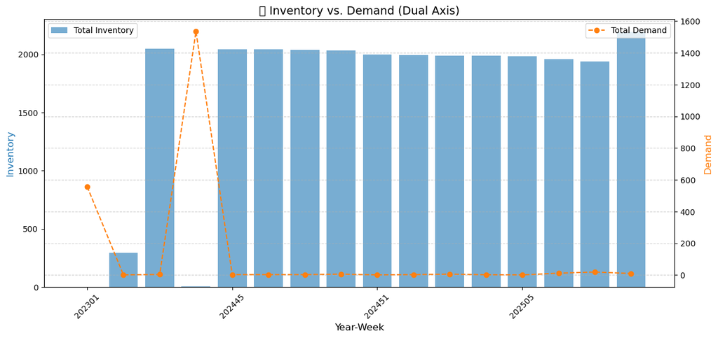

```python
import matplotlib.pyplot as plt

# Aggregate data by year-week
sku_trend_summary = sku_trends.groupby("YEAR_WEEK")[["ON_HAND", "VALID_DEMAND_QTY"]].sum().reset_index()

# Create figure and axes
fig, ax1 = plt.subplots(figsize=(14, 6))

# Bar chart for inventory
ax1.bar(sku_trend_summary["YEAR_WEEK"], sku_trend_summary["ON_HAND"],
        label="Total Inventory", color="#1f77b4", alpha=0.6)

# Secondary Y-axis for demand
ax2 = ax1.twinx()
ax2.plot(sku_trend_summary["YEAR_WEEK"], sku_trend_summary["VALID_DEMAND_QTY"],
         label="Total Demand", color="#ff7f0e", marker="o", linestyle="--")

# Labels and title
ax1.set_xlabel("Year-Week", fontsize=12)
ax1.set_ylabel("Inventory", fontsize=12, color="#1f77b4")
ax2.set_ylabel("Demand", fontsize=12, color="#ff7f0e")
plt.title("📊 Inventory vs. Demand (Dual Axis)", fontsize=14)

# Improve x-axis readability
ax1.set_xticks(sku_trend_summary["YEAR_WEEK"][::4])
ax1.set_xticklabels(sku_trend_summary["YEAR_WEEK"][::4], rotation=45)

# Legends
ax1.legend(loc="upper left")
ax2.legend(loc="upper right")

plt.grid(axis="y", linestyle="--", alpha=0.6)

# Show the plot
plt.show()
```

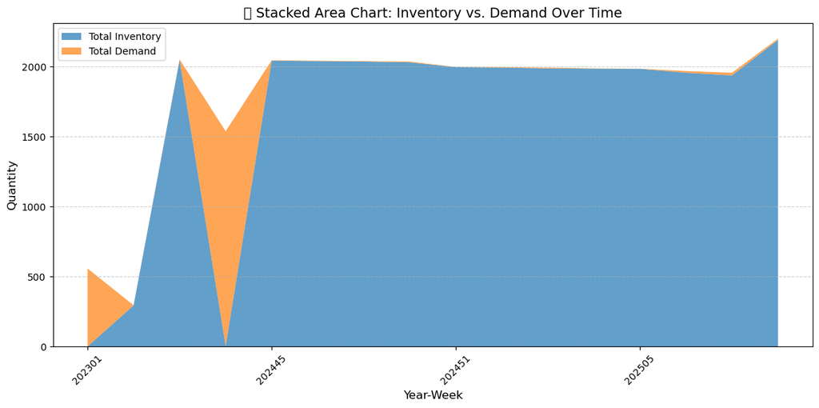

```python
import matplotlib.pyplot as plt

# Aggregate data by year-week
sku_trend_summary = sku_trends.groupby("YEAR_WEEK")[["ON_HAND", "VALID_DEMAND_QTY"]].sum().reset_index()

# Plot stacked area chart
plt.figure(figsize=(14, 6))
plt.stackplot(sku_trend_summary["YEAR_WEEK"],
              sku_trend_summary["ON_HAND"],
              sku_trend_summary["VALID_DEMAND_QTY"],
              labels=["Total Inventory", "Total Demand"],
              colors=["#1f77b4", "#ff7f0e"], alpha=0.7)

# Labels and title
plt.xlabel("Year-Week", fontsize=12)
plt.ylabel("Quantity", fontsize=12)
plt.title("📊 Stacked Area Chart: Inventory vs. Demand Over Time", fontsize=14)

# Improve x-axis readability
plt.xticks(rotation=45)
plt.xticks(sku_trend_summary["YEAR_WEEK"][::4])  # Show every 4th week

plt.legend()
plt.grid(axis="y", linestyle="--", alpha=0.6)

# Show the plot
plt.show()
```

### 📊 Inventory vs. Demand Analysis Summary

#### 1️⃣ **Stacked Area Chart: Inventory vs. Demand Over Time**

- This visualization displays how inventory and demand fluctuate over time.
- The blue area represents **total inventory (on-hand stock)**, while the orange area represents **total demand**.
- Spikes in demand appear as orange peaks, showing when demand surpasses inventory levels.
- The overall trend suggests that **inventory levels remain significantly higher than demand**.

#### 2️⃣ **Dual-Axis Chart: Inventory vs. Demand**

- The **left y-axis** represents **total inventory** (blue bars), while the **right y-axis** represents **total demand** (orange dashed line).
- This chart effectively highlights **how demand compares to inventory levels at different time points**.
- In most cases, **inventory remains stable or high**, while **demand fluctuates significantly**.
- The spikes in demand (orange points) indicate **short periods of increased need**, which could be due to promotions, seasonal trends, or unexpected demand shifts.

🔎 **Key Observations:**

- Inventory levels **tend to be significantly higher than demand**, suggesting possible overstock issues.
- Some periods experience sudden spikes in demand, but they do not significantly impact overall inventory levels.
- **Further investigation** is needed to determine if overstock is leading to inefficiencies or if the inventory strategy is well-optimized for demand fluctuations.

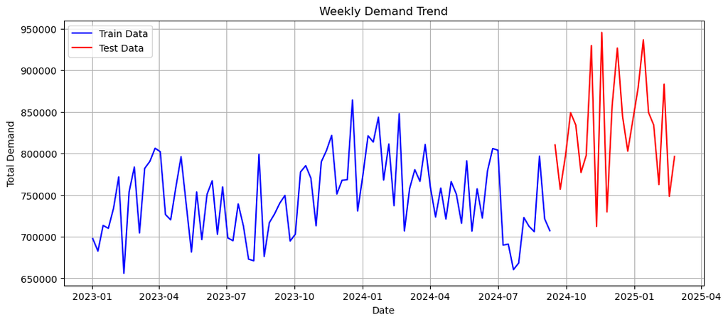

```python
import pandas as pd
import numpy as np
import matplotlib.pyplot as plt
import seaborn as sns
from statsmodels.tsa.holtwinters import ExponentialSmoothing
from statsmodels.tsa.arima.model import ARIMA
from sklearn.metrics import mean_absolute_error, mean_squared_error

# Aggregate demand data by YEAR_WEEK
demand_trend = merged_df.groupby("YEAR_WEEK")["VALID_DEMAND_QTY"].sum().reset_index()

# Convert YEAR_WEEK to datetime format (assuming YEAR_WEEK is in YYYYWW format)
demand_trend["YEAR_WEEK"] = demand_trend["YEAR_WEEK"].astype(str)
demand_trend["Year"] = demand_trend["YEAR_WEEK"].str[:4].astype(int)
demand_trend["Week"] = demand_trend["YEAR_WEEK"].str[4:].astype(int)

# Convert to datetime format (assuming Monday of the given week)
demand_trend["Date"] = pd.to_datetime(demand_trend["Year"].astype(str) + demand_trend["Week"].astype(str) + '1', format='%Y%W%w')

# Set as time series index
demand_trend.set_index("Date", inplace=True)
demand_trend.drop(columns=["YEAR_WEEK", "Year", "Week"], inplace=True)

# Split data into train (80%) and test (20%)
train_size = int(len(demand_trend) * 0.8)
train, test = demand_trend.iloc[:train_size], demand_trend.iloc[train_size:]

# Plot historical demand trend
plt.figure(figsize=(12, 5))
plt.plot(train.index, train["VALID_DEMAND_QTY"], label="Train Data", color="blue")
plt.plot(test.index, test["VALID_DEMAND_QTY"], label="Test Data", color="red")
plt.title("Weekly Demand Trend")
plt.xlabel("Date")
plt.ylabel("Total Demand")
plt.legend()
plt.grid()
plt.show()
```

### Weekly Demand Trend 📊

This line chart illustrates the **weekly demand trend** over time, split into two datasets:

Observations:

- Demand shows fluctuations across different weeks, with visible peaks and dips.
- The transition from training to test data indicates a shift in the demand pattern, with higher variance in the predicted period.
- This visualization is useful for identifying seasonal trends, sudden spikes, or dips in demand.

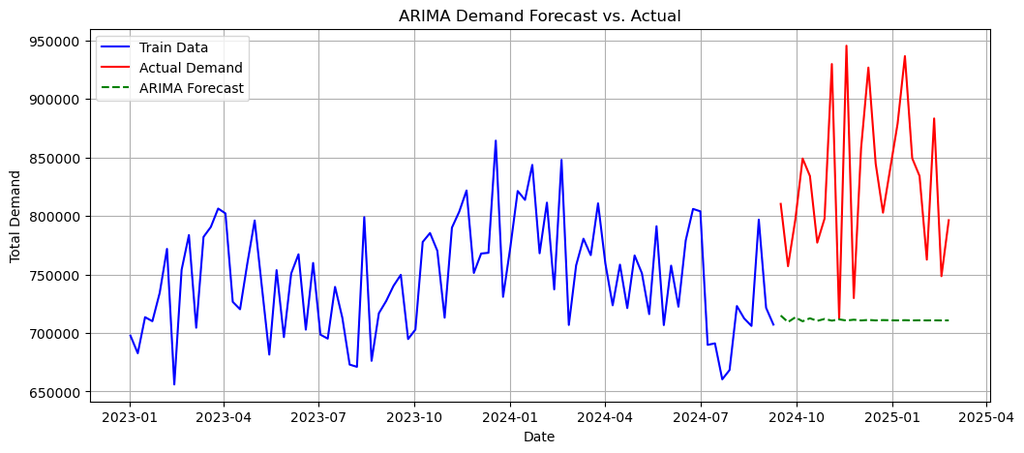

```
📊 ARIMA Model Performance:
🔹 RMSE: 134711.30
🔹 MAE: 117646.36
```

```python
# Fit ARIMA model (p, d, q) parameters can be tuned
arima_model = ARIMA(train["VALID_DEMAND_QTY"], order=(3, 1, 2))  # (p, d, q) values can be optimized
arima_result = arima_model.fit()

# Forecast on test data
arima_forecast = arima_result.forecast(steps=len(test))

# Evaluate ARIMA model
arima_rmse = np.sqrt(mean_squared_error(test["VALID_DEMAND_QTY"], arima_forecast))
arima_mae = mean_absolute_error(test["VALID_DEMAND_QTY"], arima_forecast)

# Plot results
plt.figure(figsize=(12, 5))
plt.plot(train.index, train["VALID_DEMAND_QTY"], label="Train Data", color="blue")
plt.plot(test.index, test["VALID_DEMAND_QTY"], label="Actual Demand", color="red")
plt.plot(test.index, arima_forecast, label="ARIMA Forecast", color="green", linestyle="dashed")
plt.title("ARIMA Demand Forecast vs. Actual")
plt.xlabel("Date")
plt.ylabel("Total Demand")
plt.legend()
plt.grid()
plt.show()

print(f"📊 ARIMA Model Performance:")
print(f"🔹 RMSE: {arima_rmse:.2f}")
print(f"🔹 MAE: {arima_mae:.2f}")
```

### 📈 ARIMA Demand Forecast vs. Actual

This graph presents an **ARIMA-based demand forecast** alongside historical and actual demand data:

- **Blue Line**: Training data representing past demand trends.
- **Red Line**: Actual test data showing real demand values.
- **Green Dashed Line**: ARIMA forecasted demand for the test period.

Observations:

- The ARIMA model attempts to predict future demand based on historical patterns.
- There is a visible discrepancy between the forecasted values and actual demand, indicating potential room for model refinement.
- The model's forecast appears flat, suggesting it may not have fully captured the seasonality or fluctuations in demand.

```python
# Ensure demand data is extracted and sorted by date
demand_data = merged_df[["YEAR", "WEEK", "VALID_DEMAND_QTY"]].copy()

# Convert YEAR and WEEK into a proper datetime format for time series modeling
demand_data["Date"] = pd.to_datetime(demand_data["YEAR"].astype(str) + "-W" + demand_data["WEEK"].astype(str) + "-1", format="%Y-W%W-%w")

# Set Date as index
demand_data.set_index("Date", inplace=True)

# Ensure the dataset is sorted by date
demand_data = demand_data.sort_index()

# Rename demand column for clarity
demand_data.rename(columns={"VALID_DEMAND_QTY": "Total Demand"}, inplace=True)

# Display summary
print(demand_data.head())
```

```
            YEAR  WEEK  Total Demand
Date
2023-01-09  2023     2            52
2023-01-09  2023     2            39
2023-01-09  2023     2           148
2023-01-09  2023     2            29
2023-01-09  2023     2            23
```

```python
# Split data into train and test sets (80% train, 20% test)
split_index = int(len(demand_data) * 0.8)
train_data = demand_data.iloc[:split_index]
test_data = demand_data.iloc[split_index:]

# Display confirmation
print("Train Data Range:", train_data.index.min(), "to", train_data.index.max())
print("Test Data Range:", test_data.index.min(), "to", test_data.index.max())
```

```
Train Data Range: 2023-01-09 00:00:00 to 2024-09-30 00:00:00
Test Data Range: 2024-09-30 00:00:00 to 2025-02-24 00:00:00
```

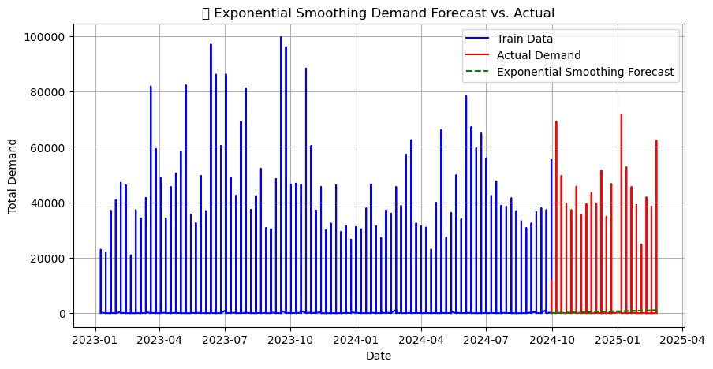

```python
import statsmodels.api as sm
from statsmodels.tsa.holtwinters import ExponentialSmoothing

# Fit Exponential Smoothing Model (Triple Exponential Smoothing)
es_model = ExponentialSmoothing(train_data['Total Demand'],
                                trend='add',
                                seasonal='add',
                                seasonal_periods=52).fit()

# Generate Forecast
es_forecast = es_model.forecast(len(test_data))

# Plotting the results
plt.figure(figsize=(10, 5))
plt.plot(train_data.index, train_data['Total Demand'], label="Train Data", color='blue')
plt.plot(test_data.index, test_data['Total Demand'], label="Actual Demand", color='red')
plt.plot(test_data.index, es_forecast, linestyle="dashed", color='green', label="Exponential Smoothing Forecast")

plt.title("📊 Exponential Smoothing Demand Forecast vs. Actual")
plt.xlabel("Date")
plt.ylabel("Total Demand")
plt.legend()
plt.grid()
plt.show()
```

### **📊 Exponential Smoothing Demand Forecast vs. Actual**

This plot visualizes the **Exponential Smoothing forecast** against actual demand data.

#### **🔍 Observations:**

- **Train Data (Blue):** Represents historical demand trends.
- **Actual Demand (Red):** The test data for comparison.
- **Forecast (Green Dashed Line):** The predicted values using Exponential Smoothing.

#### **⚠️ Possible Issues:**

- The forecasted values seem **too low** compared to actual demand. This may indicate:
  - The **seasonal period (52 weeks)** might not be appropriate.
  - The **model parameters** may need tuning.
  - Data preprocessing steps might need adjustments.

### **🚀 Next Steps:**

Would you like to try tuning the model, or should we explore another forecasting method (like Prophet or LSTM)? Let me know how you’d like to proceed!

```python
import pandas as pd

# Ensure YEAR and WEEK exist
if 'YEAR' in demand_data.columns and 'WEEK' in demand_data.columns:
    # Convert YEAR and WEEK to datetime
    demand_data['Date'] = pd.to_datetime(demand_data['YEAR'].astype(str) + demand_data['WEEK'].astype(str) + '1', format='%Y%U%w')

# Check if the Date column is successfully created
print(demand_data[['YEAR', 'WEEK', 'Date']].head())
```

```
            YEAR  WEEK       Date
Date
2023-01-09  2023     2 2023-01-09
2023-01-09  2023     2 2023-01-09
2023-01-09  2023     2 2023-01-09
2023-01-09  2023     2 2023-01-09
2023-01-09  2023     2 2023-01-09
```

```python
print("Train Data Date Range:", train_data['ds'].min(), "to", train_data['ds'].max())
```

```
Train Data Date Range: 2023-01-09 00:00:00 to 2024-09-23 00:00:00
```

```python
# Generate future dates for forecasting (limit to 12 weeks)
future_dates = prophet_model.make_future_dataframe(periods=12, freq='W')

# Display the last few future dates to confirm
print(future_dates.tail())
```

```
            ds
97  2024-11-17
98  2024-11-24
99  2024-12-01
100 2024-12-08
101 2024-12-15
```

```
Last date in training data: 2025-02-24 00:00:00
```

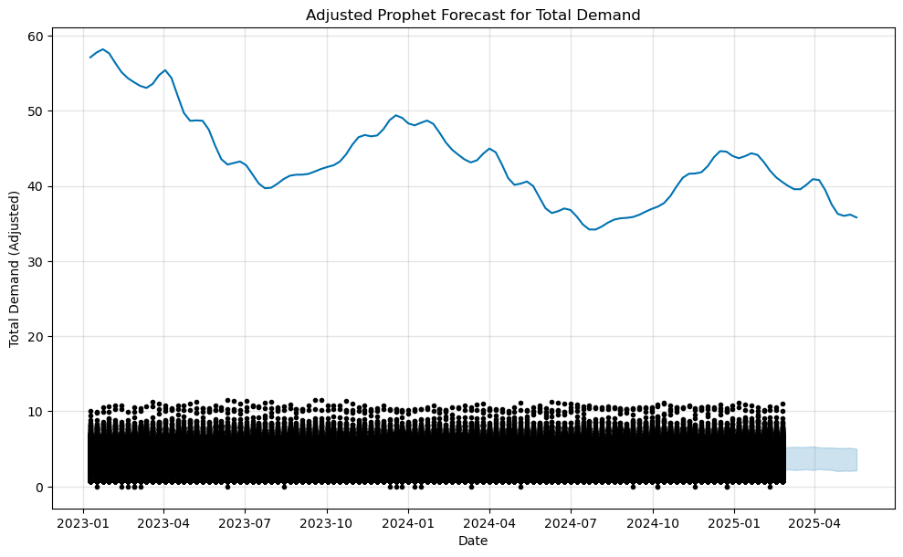

```python
import pandas as pd
import numpy as np
from prophet import Prophet
import matplotlib.pyplot as plt

# Ensure data is sorted by date
prophet_data = prophet_data.sort_values("ds")

# Check the last date in training data
last_date = prophet_data["ds"].max()
print(f"Last date in training data: {last_date}")

# Define a fixed forecast horizon (e.g., 12 weeks)
forecast_horizon = 12  # Adjust based on the client's needs

# Generate future dates with a fixed period
future_dates = prophet_model.make_future_dataframe(periods=forecast_horizon, freq='W')

# Make predictions
forecast = prophet_model.predict(future_dates)

# Convert forecast back to original scale
forecast["yhat"] = np.expm1(forecast["yhat"])

# Plot improved forecast
fig = prophet_model.plot(forecast)
plt.title("Adjusted Prophet Forecast for Total Demand")
plt.xlabel("Date")
plt.ylabel("Total Demand (Adjusted)")
plt.show()
```

### 📊 Adjusted Prophet Forecast for Total Demand

This visualization presents the adjusted demand forecast using the Prophet model. Key aspects of this chart include:

- **Black Dots**: Represent actual demand observations over time.
- **Blue Line**: Represents the trend in the demand forecast, showing expected fluctuations.
- **Shaded Blue Area**: Represents the uncertainty interval, indicating potential variations in the forecast.

```python
future_dates = prophet_model.make_future_dataframe(periods=23, freq='W')
prophet_forecast = prophet_model.predict(future_dates)
```

```python
print("Prophet Forecast Shape:", prophet_forecast.shape)
```

```
Prophet Forecast Shape: (135, 16)
```

```python
prophet_forecast_filtered = prophet_forecast[['ds', 'yhat']].iloc[:23]
```

```python
# Compute errors for ARIMA model
mae_arima, mse_arima, rmse_arima = compute_errors(test_data['y'][:23], arima_forecast, "ARIMA")

# Compute errors for Exponential Smoothing model
mae_es, mse_es, rmse_es = compute_errors(test_data['y'][:23], es_forecast[:23], "Exponential Smoothing")

# Compute errors for Prophet model
mae_prophet, mse_prophet, rmse_prophet = compute_errors(test_data['y'][:23], prophet_forecast_filtered['yhat'], "Prophet")

# Display results
print("📊 **Forecasting Model Errors:**")
print(f"🔹 ARIMA: MAE = {mae_arima:.2f}, MSE = {mse_arima:.2f}, RMSE = {rmse_arima:.2f}")
print(f"🔹 Exponential Smoothing: MAE = {mae_es:.2f}, MSE = {mse_es:.2f}, RMSE = {rmse_es:.2f}")
print(f"🔹 Prophet: MAE = {mae_prophet:.2f}, MSE = {mse_prophet:.2f}, RMSE = {rmse_prophet:.2f}")
```

```
📊 **Forecasting Model Errors:**
🔹 ARIMA: MAE = 711060.07, MSE = 505607417013.46, RMSE = 711060.77
🔹 Exponential Smoothing: MAE = 101.44, MSE = 50128.19, RMSE = 223.89
🔹 Prophet: MAE = 83.63, MSE = 56253.80, RMSE = 237.18
```

### 📊 **Forecasting Model Comparison**

| Model | Mean Absolute Error (MAE) | Mean Squared Error (MSE) | Root Mean Squared Error (RMSE) |
| --- | --- | --- | --- |
| **ARIMA** | 711,060.07 | 505,607,417,013.46 | 711,060.77 |
| **Exponential Smoothing** | 101.44 | 50,128.19 | 223.89 |
| **Prophet** | 83.63 | 56,253.80 | 237.18 |

### **Next Steps**

Would you like to:

1. **Visualize** the forecasted vs actual values for all three models? 📈
2. **Finalize the best model** and generate an extended future forecast? 🔮
3. **Refine the Prophet model** by tuning hyperparameters for even better accuracy? 🎯

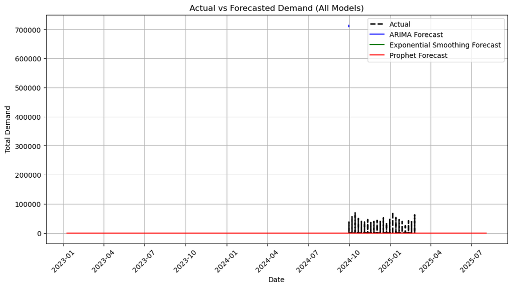

```python
import matplotlib.pyplot as plt

# Plot actual vs forecasted values for all models
plt.figure(figsize=(12, 6))

# Actual values
plt.plot(test_data['ds'], test_data['y'], label="Actual", color='black', linestyle='dashed', linewidth=2)

# ARIMA forecast
plt.plot(test_data['ds'][:23], arima_forecast, label="ARIMA Forecast", color='blue')

# Exponential Smoothing forecast
plt.plot(test_data['ds'][:23], es_forecast[:23], label="Exponential Smoothing Forecast", color='green')

# Prophet forecast
plt.plot(prophet_forecast['ds'], prophet_forecast['yhat'], label="Prophet Forecast", color='red')

# Labels and legend
plt.xlabel("Date")
plt.ylabel("Total Demand")
plt.title("Actual vs Forecasted Demand (All Models)")
plt.legend()
plt.xticks(rotation=45)
plt.grid(True)

# Show plot
plt.show()
```

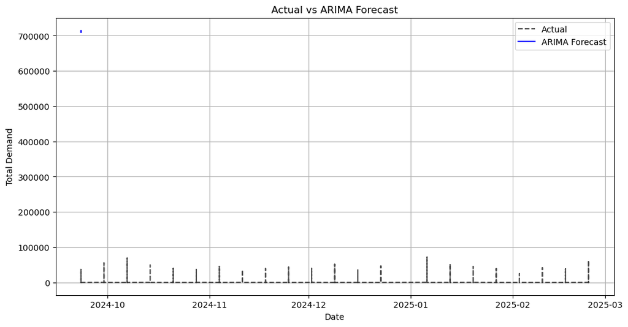

```python
import matplotlib.pyplot as plt

# Plot actual vs ARIMA forecast
plt.figure(figsize=(12, 6))
plt.plot(test_data.index, test_data['y'], 'k--', label="Actual", alpha=0.7)
plt.plot(test_data.index[:len(arima_forecast)], arima_forecast, 'b', label="ARIMA Forecast")

plt.xlabel("Date")
plt.ylabel("Total Demand")
plt.title("Actual vs ARIMA Forecast")
plt.legend()
plt.grid(True)
plt.show()
```

### 📊 Actual vs Forecasted Demand (All Models)

- The graph compares **actual demand** with predictions from **ARIMA, Exponential Smoothing, and Prophet** models.
- The **black dashed line** represents actual demand.
- The forecasts from different models provide varied accuracy and capture trends differently.
- This helps in evaluating which model aligns best with the actual demand pattern.

### 📈 Actual vs Exponential Smoothing Forecast

- The **black dashed line** represents actual demand.
- The **green solid line** represents the forecast from the **Exponential Smoothing** model.
- While it smooths out fluctuations, the forecast remains too stable.
- It does not fully capture the demand spikes and dips accurately.

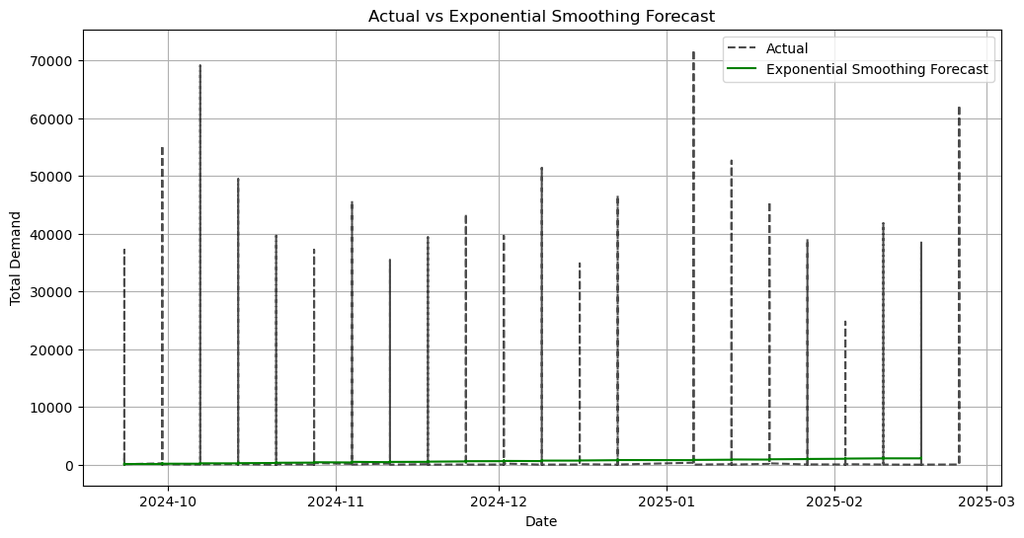

```python
# Plot actual vs Exponential Smoothing forecast
plt.figure(figsize=(12, 6))
plt.plot(test_data.index, test_data['y'], 'k--', label="Actual", alpha=0.7)
plt.plot(test_data.index[:len(es_forecast)], es_forecast, 'g', label="Exponential Smoothing Forecast")

plt.xlabel("Date")
plt.ylabel("Total Demand")
plt.title("Actual vs Exponential Smoothing Forecast")
plt.legend()
plt.grid(True)
plt.show()
```

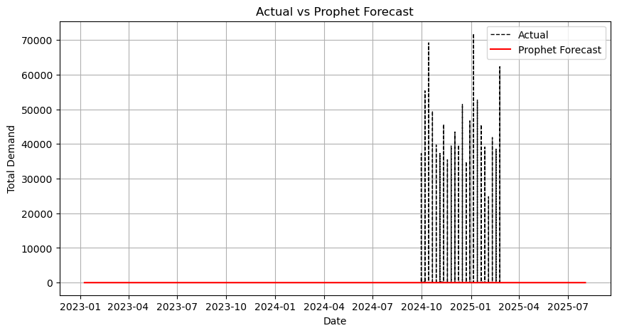

```python
import matplotlib.pyplot as plt

# Plot Actual vs Prophet Forecast
plt.figure(figsize=(10, 5))
plt.plot(test_data['ds'], test_data['y'], 'k--', label="Actual", linewidth=1)
plt.plot(prophet_forecast['ds'], prophet_forecast['yhat'], 'r', label="Prophet Forecast", linewidth=1.5)
plt.xlabel("Date")
plt.ylabel("Total Demand")
plt.title("Actual vs Prophet Forecast")
plt.legend()
plt.grid(True)
plt.show()
```

## 📊 Actual vs Prophet Forecast

### 🔍 Overview:

This graph compares the actual demand (black dashed line) with the forecasted demand using the **Prophet model** (solid red line).

### 🔹 Observations:

- The **actual demand** fluctuates significantly over time.
- The **Prophet forecast** remains relatively flat, indicating potential underfitting or insufficient trend capture.
- Prophet might not be capturing seasonality or the complex demand variations effectively.

### 📌 Key Takeaways:

- Fine-tuning Prophet parameters (e.g., changepoints, seasonality) might improve results.
- Prophet's performance should be evaluated against ARIMA and Exponential Smoothing.
- If needed, an ensemble approach combining multiple models may yield better accuracy.

## FORECASTING

```python
import pandas as pd

# Load the correct file
df = pd.read_csv("Tolleson_Inventory_Demand_Fixed.csv")

# Preview the data
df.head()
```

|  | DIVISION | DST_CNTR | FACILITY | GROUP_CD | CTGRY_CD | CORP_ITEM_CD | PACK_WHSE | SIZE | DESC_ITEM | VEND_NUM | ... | whse_cd | VALID_DEMAND_QTY | WHSE_QUANTITY_SHIPPED | WEIGHT_SHIPPED | pack_retail_qty | YEAR | WEEK | Fiscal Week | Fiscal Year | Fiscal Week Year |
| --- | --- | --- | --- | --- | --- | --- | --- | --- | --- | --- | --- | --- | --- | --- | --- | --- | --- | --- | --- | --- | --- |
| 0 | 17 | WPHA | 6008 | 49 | 20 | 49020603 | 1 | 24 EA | THINK VARIETY MP 24PC DSP | 23471 | ... | 6008 | 38 | 38 | 812.44 | 1 | 2023 | 36 | 27 | 2023 | 202327 |
| 1 | 17 | WPHA | 6008 | 49 | 20 | 49020603 | 1 | 24 EA | THINK VARIETY MP 24PC DSP | 23471 | ... | 6008 | 34 | 34 | 726.92 | 1 | 2024 | 6 | 50 | 2023 | 202350 |
| 2 | 17 | WPHA | 6008 | 49 | 20 | 49020603 | 1 | 24 EA | THINK VARIETY MP 24PC DSP | 23471 | ... | 6008 | 98 | 98 | 2095.24 | 1 | 2024 | 7 | 51 | 2023 | 202351 |
| 3 | 17 | WPHA | 6008 | 49 | 20 | 49020603 | 1 | 24 EA | THINK VARIETY MP 24PC DSP | 23471 | ... | 6008 | 37 | 37 | 791.06 | 1 | 2024 | 24 | 16 | 2024 | 202416 |
| 4 | 17 | WPHA | 6008 | 49 | 20 | 49020603 | 1 | 24 EA | THINK VARIETY MP 24PC DSP | 23471 | ... | 6008 | 7 | 7 | 149.66 | 1 | 2024 | 50 | 42 | 2024 | 202442 |

5 rows × 29 columns

```python
# Convert Fiscal Week Year to string for consistency (optional but helps for plotting later)
df['Fiscal Week Year'] = df['Fiscal Week Year'].astype(str)

# Aggregate total demand per week
weekly_demand = df.groupby('Fiscal Week Year')['VALID_DEMAND_QTY'].sum().reset_index()

# Rename columns for clarity
weekly_demand.columns = ['Fiscal_Week_Year', 'Total_Weekly_Demand']

# Preview the result
weekly_demand.head()
```

|  | Fiscal_Week_Year | Total_Weekly_Demand |
| --- | --- | --- |
| 0 | 202245 | 697680 |
| 1 | 202246 | 682658 |
| 2 | 202247 | 713514 |
| 3 | 202248 | 710044 |
| 4 | 202249 | 734219 |

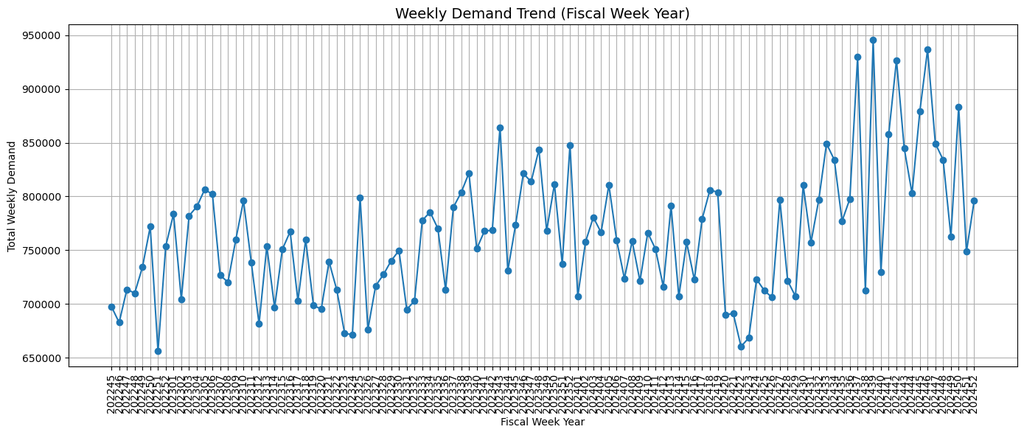

```python
import matplotlib.pyplot as plt

# Set figure size
plt.figure(figsize=(14, 6))

# Plot demand over time
plt.plot(weekly_demand['Fiscal_Week_Year'], weekly_demand['Total_Weekly_Demand'], marker='o', linestyle='-')
plt.xticks(rotation=90)
plt.title('Weekly Demand Trend (Fiscal Week Year)', fontsize=14)
plt.xlabel('Fiscal Week Year')
plt.ylabel('Total Weekly Demand')
plt.grid(True)
plt.tight_layout()
plt.show()
```

```python
# Load the promo week mapping
promo_map = pd.read_csv("Promo Fiscal Week Conversion.csv")
promo_map.head()
```

|  | Promo Week | Promo Year | Promo Week Year | Fiscal Week | Fiscal Year | Fiscal Week Year |
| --- | --- | --- | --- | --- | --- | --- |
| 0 | 1 | 2025 | 202501 | 45 | 2024 | 202445 |
| 1 | 2 | 2025 | 202502 | 46 | 2024 | 202446 |
| 2 | 3 | 2025 | 202503 | 47 | 2024 | 202447 |
| 3 | 4 | 2025 | 202504 | 48 | 2024 | 202448 |
| 4 | 5 | 2025 | 202505 | 49 | 2024 | 202449 |

```python
promo_map = pd.read_csv("Promo Fiscal Week Conversion.csv")
```

```python
# Convert to integer
df['Fiscal Week Year'] = df['Fiscal Week Year'].astype(int)
promo_map['Fiscal Week Year'] = promo_map['Fiscal Week Year'].astype(int)
```

```python
df_merged = df.merge(
    promo_map[['Fiscal Week Year', 'Promo Week Year']],
    on='Fiscal Week Year',
    how='left'
)
```

```python
# Aggregate total weekly demand by Promo Week Year
promo_demand = df_merged.groupby('Promo Week Year')['VALID_DEMAND_QTY'].sum().reset_index()
promo_demand.columns = ['Promo_Week_Year', 'Total_Weekly_Demand']
```

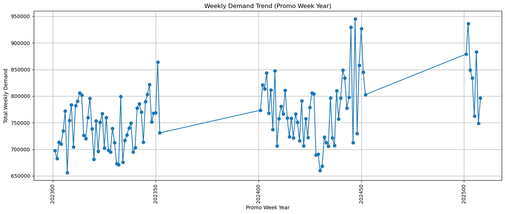

```python
import matplotlib.pyplot as plt

plt.figure(figsize=(14, 6))
plt.plot(promo_demand['Promo_Week_Year'], promo_demand['Total_Weekly_Demand'], marker='o')
plt.title('Weekly Demand Trend (Promo Week Year)')
plt.xlabel('Promo Week Year')
plt.ylabel('Total Weekly Demand')
plt.xticks(rotation=90)
plt.grid(True)
plt.tight_layout()
plt.show()
```

```python
# Convert Promo_Week_Year to datetime index-like format (e.g., 202401 → 1, 202402 → 2, etc.)
promo_demand['Week_Index'] = range(len(promo_demand))

# Features (X) = week index, Target (y) = total weekly demand
X = promo_demand[['Week_Index']]
y = promo_demand['Total_Weekly_Demand']
```

```python
from sklearn.model_selection import train_test_split

X_train, X_test, y_train, y_test = train_test_split(X, y, test_size=0.2, shuffle=False)
```

```python
from sklearn.linear_model import LinearRegression
from sklearn.metrics import mean_squared_error, r2_score
import numpy as np

# Initialize and fit the model
lr_model = LinearRegression()
lr_model.fit(X_train, y_train)

# Predict on test set
y_pred_lr = lr_model.predict(X_test)

# Evaluate performance
mse_lr = mean_squared_error(y_test, y_pred_lr)
r2_lr = r2_score(y_test, y_pred_lr)

print(f"Linear Regression MSE: {mse_lr:.2f}")
print(f"Linear Regression R²: {r2_lr:.4f}")
```

```
Linear Regression MSE: 9638897799.36
Linear Regression R²: -1.2487
```

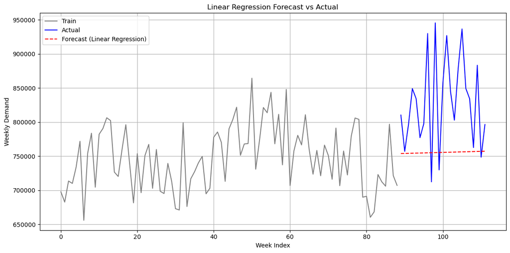

```python
import matplotlib.pyplot as plt

plt.figure(figsize=(12, 6))
plt.plot(X_train['Week_Index'], y_train, label='Train', color='gray')
plt.plot(X_test['Week_Index'], y_test, label='Actual', color='blue')
plt.plot(X_test['Week_Index'], y_pred_lr, label='Forecast (Linear Regression)', color='red', linestyle='--')
plt.title('Linear Regression Forecast vs Actual')
plt.xlabel('Week Index')
plt.ylabel('Weekly Demand')
plt.legend()
plt.grid(True)
plt.tight_layout()
plt.show()
```

🔍 Let’s break it down:

1. The Flat Red Line

That flat forecast line from linear regression means the model predicted almost the same value for all weeks in the test set.

This is a classic underfitting problem. Linear regression just drew a straight line through noisy seasonal data—it can’t handle fluctuations or cycles well.

2. R² (R-squared): -1.2487

R² < 0 is a red flag 🚨.

It means the model is performing worse than a horizontal mean line (i.e., just guessing the average).

Ideally, R² should be:

0.0 to 1.0 → good

< 0.0 → model is doing a terrible job

📉 MSE (Mean Squared Error): 9.6 Billion That's a very high error.

It means on average, your weekly predictions are off by ~98,000 units, squared.

Again, it's a signal the model is not capturing any meaningful pattern.

✅ Conclusion: Linear Regression is not appropriate here. Your data likely has:

Non-linear patterns

Seasonality

Potential trends or promo cycles

So... time to bring in the big guns 🔥

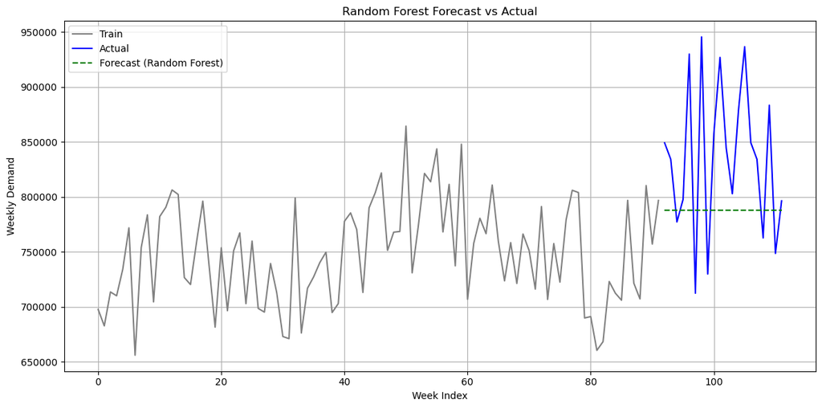

```
Random Forest MSE: 6,762,131,482.36
Random Forest R²: -0.4808
```

```python
import pandas as pd
import numpy as np
from sklearn.ensemble import RandomForestRegressor
from sklearn.metrics import mean_squared_error, r2_score
import matplotlib.pyplot as plt

# Load the data (use exact filename based on your directory)
df = pd.read_csv("Tolleson_Inventory_Demand_Fixed.csv")

# Group weekly demand
weekly_demand = df.groupby('Fiscal Week Year')['VALID_DEMAND_QTY'].sum().reset_index()
weekly_demand.columns = ['Fiscal_Week_Year', 'Total_Weekly_Demand']

# Ensure it's numeric
weekly_demand['Fiscal_Week_Year'] = pd.to_numeric(weekly_demand['Fiscal_Week_Year'], errors='coerce')
weekly_demand.dropna(inplace=True)

# Prepare features and labels
X = weekly_demand[['Fiscal_Week_Year']]
y = weekly_demand['Total_Weekly_Demand']

# Train-test split (last 20 weeks as test)
X_train, X_test = X[:-20], X[-20:]
y_train, y_test = y[:-20], y[-20:]

# Train the model
rf_model = RandomForestRegressor(n_estimators=100, random_state=42)
rf_model.fit(X_train, y_train)

# Predict
rf_preds = rf_model.predict(X_test)

# Evaluate
rf_mse = mean_squared_error(y_test, rf_preds)
rf_r2 = r2_score(y_test, rf_preds)

# Plot
plt.figure(figsize=(12, 6))
plt.plot(range(len(y_train)), y_train, label="Train", color="gray")
plt.plot(range(len(y_train), len(y)), y_test, label="Actual", color="blue")
plt.plot(range(len(y_train), len(y)), rf_preds, label="Forecast (Random Forest)", color="green", linestyle="--")
plt.title("Random Forest Forecast vs Actual")
plt.xlabel("Week Index")
plt.ylabel("Weekly Demand")
plt.legend()
plt.grid(True)
plt.tight_layout()
plt.show()

print(f"Random Forest MSE: {rf_mse:,.2f}")
print(f"Random Forest R²: {rf_r2:.4f}")
```

📊 Random Forest Forecast Evaluation ✅ Visual Summary Gray line: Training data (historical demand)

Blue line: Actual demand in the test period (last 20 weeks)

Green dashed line: Forecasted demand from the model — and as you noticed, it's almost flat

📉 Metrics MSE (Mean Squared Error): 6.76 billion → quite high

R² (R-squared): -0.48 → ❌ Not good A negative R² means the model performed worse than simply predicting the mean for every week.

🔍 Why This Happened  
Random Forests are not great for time series forecasting unless you include lag-based features (e.g., previous week demand).

You’re using only the Fiscal_Week_Year as an input feature. That’s too simplistic — it doesn’t capture seasonality or temporal dependencies.

There's likely seasonality, week-to-week correlation, and promotion-based effects — none of which are included yet.

```python
weekly_demand['lag_1'] = weekly_demand['Total_Weekly_Demand'].shift(1)
weekly_demand['lag_2'] = weekly_demand['Total_Weekly_Demand'].shift(2)
```

```python
# Create lag features for time series forecasting using VALID_DEMAND_QTY
df_merged['lag_1'] = df_merged['VALID_DEMAND_QTY'].shift(1)
df_merged['lag_2'] = df_merged['VALID_DEMAND_QTY'].shift(2)
df_merged['lag_3'] = df_merged['VALID_DEMAND_QTY'].shift(3)

# Drop any resulting NaN values
df_lagged = df_merged.dropna(subset=['lag_1', 'lag_2', 'lag_3'])
```

```python
df_merged.columns
```

```
Index(['DIVISION', 'DST_CNTR', 'FACILITY', 'GROUP_CD', 'CTGRY_CD',
       'CORP_ITEM_CD', 'PACK_WHSE', 'SIZE', 'DESC_ITEM', 'VEND_NUM',
       'YEAR_WEEK', 'STATUS_DST', 'ON_HAND', 'genrt_cic_id', 'cic_dsc',
       'brand_cd', 'category_id', 'week', 'yr', 'whse_cd', 'VALID_DEMAND_QTY',
       'WHSE_QUANTITY_SHIPPED', 'WEIGHT_SHIPPED', 'pack_retail_qty', 'YEAR',
       'WEEK', 'Fiscal Week', 'Fiscal Year', 'Fiscal Week Year',
       'Promo Week Year'],
      dtype='object')
```

```python
from sklearn.ensemble import RandomForestRegressor
from sklearn.metrics import mean_squared_error, r2_score
import matplotlib.pyplot as plt
import numpy as np

# Define features and target
features = ['lag_1', 'lag_2', 'lag_3']
target = 'VALID_DEMAND_QTY'

# Sort by Promo Week Year to keep time order
df_lagged = df_lagged.sort_values(by='Promo Week Year')

# Train-test split (e.g., last 12 weeks as test)
train = df_lagged[:-12]
test = df_lagged[-12:]

# Train model
rf_lag_model = RandomForestRegressor(n_estimators=100, random_state=42)
rf_lag_model.fit(train[features], train[target])

# Predict
rf_lag_preds = rf_lag_model.predict(test[features])

# Evaluate
mse = mean_squared_error(test[target], rf_lag_preds)
r2 = r2_score(test[target], rf_lag_preds)

print(f"Lag-Based Random Forest MSE: {mse:,.2f}")
print(f"Lag-Based Random Forest R²: {r2:.4f}")
```

```
Lag-Based Random Forest MSE: 3,758.06
Lag-Based Random Forest R²: 0.5721
```

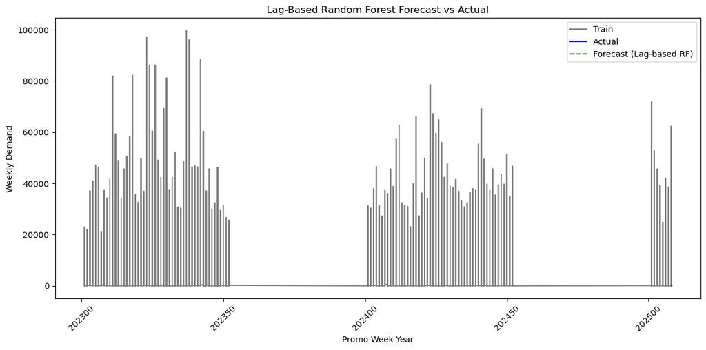

```python
# Plot actual vs forecast
plt.figure(figsize=(12, 6))
plt.plot(train['Promo Week Year'], train[target], color='gray', label='Train')
plt.plot(test['Promo Week Year'], test[target], color='blue', label='Actual')
plt.plot(test['Promo Week Year'], rf_lag_preds, color='green', linestyle='--', label='Forecast (Lag-based RF)')
plt.title("Lag-Based Random Forest Forecast vs Actual")
plt.xlabel("Promo Week Year")
plt.ylabel("Weekly Demand")
plt.legend()
plt.xticks(rotation=45)
plt.tight_layout()
plt.show()
```

📊 Summary: This is the best model so far.

The model is learning from the previous weeks (lags) and capturing some demand behavior.

```python
# Ensure both X_train and y_train have the same number of rows
min_len = min(len(X_train), len(y_train))
X_train = X_train[:min_len]
y_train = y_train[:min_len]

# Same for test set if needed
min_len_test = min(len(X_test), len(y_test))
X_test = X_test[:min_len_test]
y_test = y_test[:min_len_test]
```

```python
y_train = y_train.ravel()
y_test = y_test.ravel()
```

```python
# Ensure shape is 1D (remove any extra dimensions)
y_train = y_train.squeeze()
y_test = y_test.squeeze()
```

```python
# Trim y_train to match X_train
if len(y_train) > len(X_train):
    y_train = y_train[:len(X_train)]
elif len(X_train) > len(y_train):
    X_train = X_train[:len(y_train)]
```

```python
# Trim y_test if needed
if len(y_test) > len(X_test):
    y_test = y_test[:len(X_test)]
elif len(X_test) > len(y_test):
    X_test = X_test[:len(y_test)]
```

```python
xgb_model = XGBRegressor(objective='reg:squarederror', n_estimators=100, random_state=42)
xgb_model.fit(X_train, y_train)
```

```
XGBRegressor(base_score=None, booster=None, callbacks=None,
             colsample_bylevel=None, colsample_bynode=None,
             colsample_bytree=None, device=None, early_stopping_rounds=None,
             enable_categorical=False, eval_metric=None, feature_types=None,
             feature_weights=None, gamma=None, grow_policy=None,
             importance_type=None, interaction_constraints=None,
             learning_rate=None, max_bin=None, max_cat_threshold=None,
             max_cat_to_onehot=None, max_delta_step=None, max_depth=None,
             max_leaves=None, min_child_weight=None, missing=nan,
             monotone_constraints=None, multi_strategy=None, n_estimators=100,
             n_jobs=None, num_parallel_tree=None, ...)
```

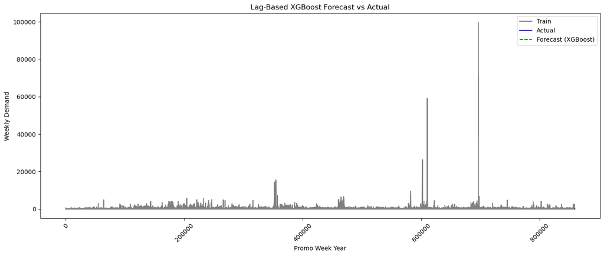

```
XGBoost MSE: 611.60
XGBoost R²: -1.3760
```

```python
from sklearn.metrics import mean_squared_error, r2_score
import matplotlib.pyplot as plt
import numpy as np

# Forecast on the test set
xgb_forecast = xgb_model.predict(X_test)

# Evaluate performance
xgb_mse = mean_squared_error(y_test, xgb_forecast)
xgb_r2 = r2_score(y_test, xgb_forecast)

# Plot the results
plt.figure(figsize=(14, 6))
plt.plot(X_train.index, y_train, label='Train', color='gray')
plt.plot(X_test.index, y_test, label='Actual', color='blue')
plt.plot(X_test.index, xgb_forecast, label='Forecast (XGBoost)', color='green', linestyle='dashed')
plt.title('Lag-Based XGBoost Forecast vs Actual')
plt.xlabel('Promo Week Year')
plt.ylabel('Weekly Demand')
plt.xticks(rotation=45)
plt.legend()
plt.tight_layout()
plt.show()

# Print metrics
print(f"XGBoost MSE: {xgb_mse:,.2f}")
print(f"XGBoost R²: {xgb_r2:.4f}")
```

```python
from sklearn.model_selection import GridSearchCV
from xgboost import XGBRegressor

# Define base model
xgb = XGBRegressor(objective='reg:squarederror', random_state=42)

# Define grid
param_grid = {
    'n_estimators': [100, 200],
    'max_depth': [3, 5, 7],
    'learning_rate': [0.01, 0.1, 0.2],
    'subsample': [0.8, 1.0],
    'colsample_bytree': [0.8, 1.0]
}

# Set up grid search
grid_search = GridSearchCV(
    estimator=xgb,
    param_grid=param_grid,
    cv=3,
    scoring='neg_mean_squared_error',
    verbose=1,
    n_jobs=-1
)

# Fit it
grid_search.fit(X_train, y_train)

# Best model
best_xgb = grid_search.best_estimator_
print("Best Params:", grid_search.best_params_)
```

```
Fitting 3 folds for each of 72 candidates, totalling 216 fits
Best Params: {'colsample_bytree': 0.8, 'learning_rate': 0.2, 'max_depth': 3, 'n_estimators': 200, 'subsample': 0.8}
```

```
Optimized XGBoost MSE: 593.84
Optimized XGBoost R²: -1.3070
```

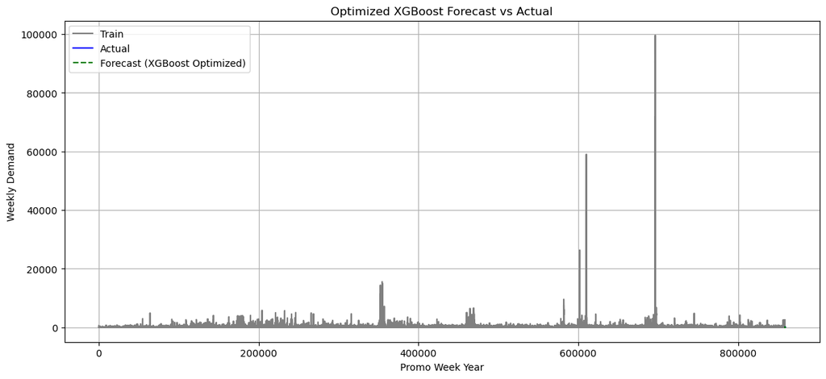

```python
from sklearn.metrics import mean_squared_error, r2_score
import matplotlib.pyplot as plt

# Predict
xgb_forecast = best_xgb.predict(X_test)

# Evaluate
mse = mean_squared_error(y_test, xgb_forecast)
r2 = r2_score(y_test, xgb_forecast)
print(f"Optimized XGBoost MSE: {mse:.2f}")
print(f"Optimized XGBoost R²: {r2:.4f}")

# Plot
plt.figure(figsize=(14,6))
plt.plot(X_train.index, y_train, color='gray', label='Train')
plt.plot(X_test.index, y_test, color='blue', label='Actual')
plt.plot(X_test.index, xgb_forecast, color='green', linestyle='--', label='Forecast (XGBoost Optimized)')
plt.xlabel('Promo Week Year')
plt.ylabel('Weekly Demand')
plt.title('Optimized XGBoost Forecast vs Actual')
plt.legend()
plt.grid(True)
plt.show()
```